# Simulations

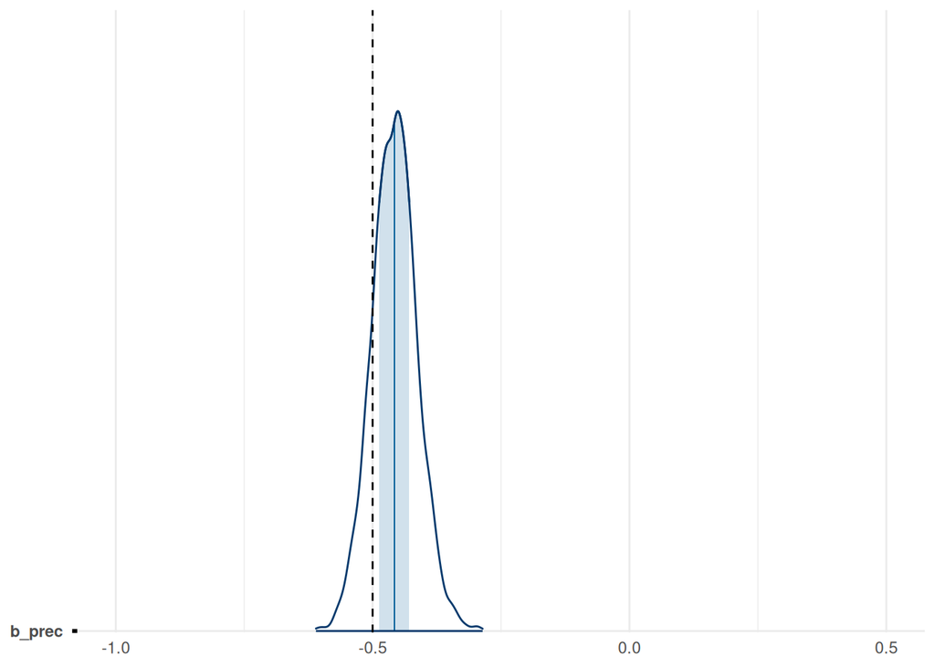

```r
fit_naive_pos |>
  coefplot(-0.5, c(-1, 0.5), pars = "b_prec")
```

```r
fit_naive_nul <- update(fit_naive_pos,
                        newdata = sim_nul,
                        file = "fits/sim/sim.nai.nul",
                        seed = 295)

fit_naive_nul
```

```
 Family: gaussian
  Links: mu = identity
Formula: FD ~ temp + prec + (1 | site)
   Data: sim_nul (Number of observations: 512)
  Draws: 4 chains, each with iter = 2000; warmup = 1000; thin = 1;
         total post-warmup draws = 4000

Multilevel Hyperparameters:
~site (Number of levels: 4)
              Estimate Est.Error l-95% CI u-95% CI Rhat Bulk_ESS Tail_ESS
sd(Intercept)     1.30      0.43     0.73     2.39 1.00     1174     1923

Regression Coefficients:
          Estimate Est.Error l-95% CI u-95% CI Rhat Bulk_ESS Tail_ESS
Intercept     0.11      0.49    -0.86     1.08 1.01     1101     1406
temp          0.01      0.05    -0.09     0.11 1.00     3260     2447
prec         -0.46      0.04    -0.55    -0.37 1.00     2984     2344

Further Distributional Parameters:
      Estimate Est.Error l-95% CI u-95% CI Rhat Bulk_ESS Tail_ESS
sigma     0.51      0.02     0.48     0.55 1.00     3546     2042

Draws were sampled using sample(hmc). For each parameter, Bulk_ESS
and Tail_ESS are effective sample size measures, and Rhat is the potential
scale reduction factor on split chains (at convergence, Rhat = 1).
```

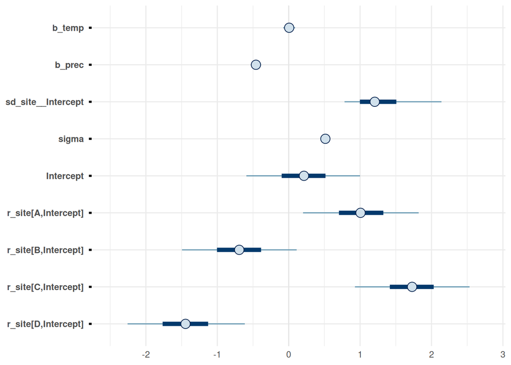

```r
mcmc_intervals(fit_naive_nul, pars = show)
```

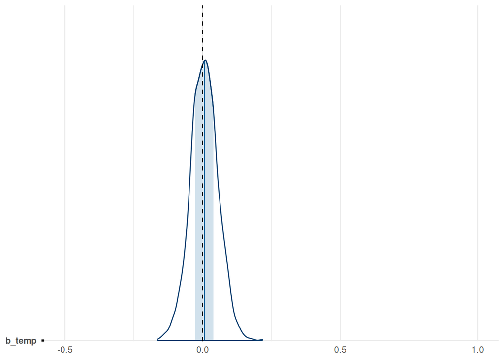

```r
fit_naive_nul |>
  coefplot(0, c(-0.5, 1))
```

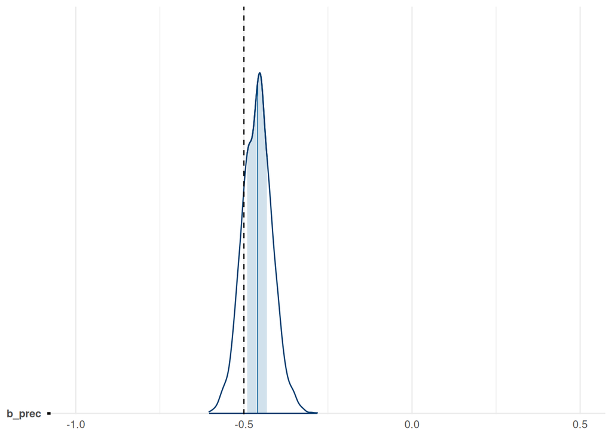

```r
fit_naive_nul |>
  coefplot(-0.5, c(-1, 0.5), pars = "b_prec")
```

```r
fit_naive_neg <- update(fit_naive_pos,
                        newdata = sim_neg,
                        file = "fits/sim/sim.nai.neg",
                        seed = 295)

fit_naive_neg
```

```
 Family: gaussian
  Links: mu = identity
Formula: FD ~ temp + prec + (1 | site)
   Data: sim_neg (Number of observations: 512)
  Draws: 4 chains, each with iter = 2000; warmup = 1000; thin = 1;
         total post-warmup draws = 4000

Multilevel Hyperparameters:
~site (Number of levels: 4)
              Estimate Est.Error l-95% CI u-95% CI Rhat Bulk_ESS Tail_ESS
sd(Intercept)     1.37      0.49     0.74     2.54 1.00     1094     1525

Regression Coefficients:
          Estimate Est.Error l-95% CI u-95% CI Rhat Bulk_ESS Tail_ESS
Intercept    -0.22      0.58    -1.37     0.89 1.00     1017     1239
temp         -0.99      0.05    -1.09    -0.89 1.00     2601     2182
prec         -0.46      0.04    -0.55    -0.37 1.00     3024     2312

Further Distributional Parameters:
      Estimate Est.Error l-95% CI u-95% CI Rhat Bulk_ESS Tail_ESS
sigma     0.51      0.02     0.48     0.55 1.00     2778     2159

Draws were sampled using sample(hmc). For each parameter, Bulk_ESS
and Tail_ESS are effective sample size measures, and Rhat is the potential
scale reduction factor on split chains (at convergence, Rhat = 1).
```

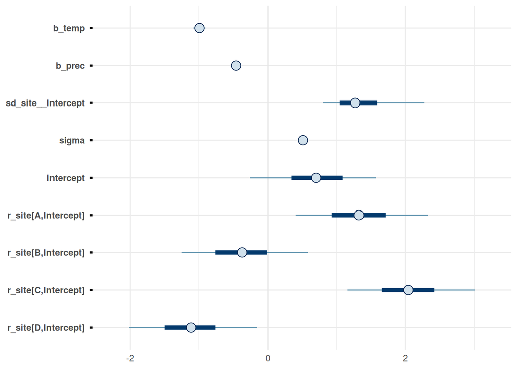

```r
mcmc_intervals(fit_naive_neg, pars = show)
```

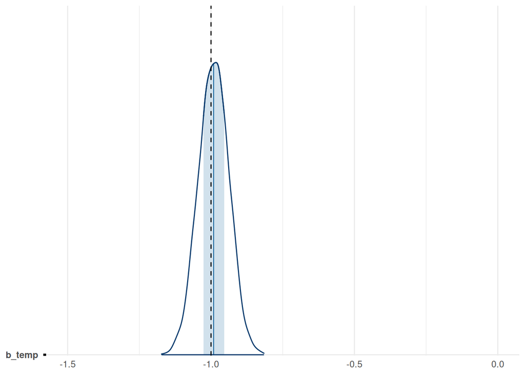

```r
fit_naive_neg |>
  coefplot(-1, c(-1.5, 0))
```

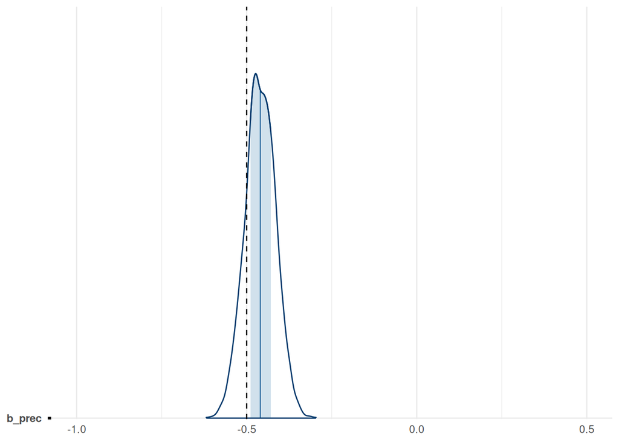

```r
fit_naive_neg |>
  coefplot(-0.5, c(-1, 0.5), pars = "b_prec")
```

## 5.4 Mundlak contextual model

The Mundlak model adjusts for the group-level (site) mean to account for group-level confounding (Mundlak 1978). It will recover two coefficients, one the true within-site effect, one the contextual effect, a confounded effect representing the influence of being in a different site with the same temperature, that is the difference in between- and within-site slopes.

```r
fit_mund_pos <- brm(FD ~ temp + t_mean + prec + p_mean + (1|site),
                    data = sim_pos,
                    prior = prior_re,
                    file = "fits/sim/sim.mund.pos",
                    seed = 295,
                    control = list(adapt_delta = 0.99))

fit_mund_pos
```

```
 Family: gaussian
  Links: mu = identity
Formula: FD ~ temp + t_mean + prec + p_mean + (1 | site)
   Data: sim_pos (Number of observations: 512)
  Draws: 4 chains, each with iter = 2000; warmup = 1000; thin = 1;
         total post-warmup draws = 4000

Multilevel Hyperparameters:
~site (Number of levels: 4)
              Estimate Est.Error l-95% CI u-95% CI Rhat Bulk_ESS Tail_ESS
sd(Intercept)     0.21      0.23     0.01     0.84 1.01      532      796

Regression Coefficients:
          Estimate Est.Error l-95% CI u-95% CI Rhat Bulk_ESS Tail_ESS
Intercept    -0.34      0.24    -0.73     0.32 1.01     1417      776
temp          1.00      0.05     0.90     1.10 1.00     2280     2475
t_mean       -0.12      0.17    -0.43     0.31 1.01     1490      814
prec         -0.45      0.05    -0.54    -0.36 1.00     3715     3265
p_mean       -1.15      0.18    -1.43    -0.72 1.01     1210      823

Further Distributional Parameters:
      Estimate Est.Error l-95% CI u-95% CI Rhat Bulk_ESS Tail_ESS
sigma     0.51      0.02     0.48     0.55 1.00     3440     1964

Draws were sampled using sample(hmc). For each parameter, Bulk_ESS
and Tail_ESS are effective sample size measures, and Rhat is the potential
scale reduction factor on split chains (at convergence, Rhat = 1).
```

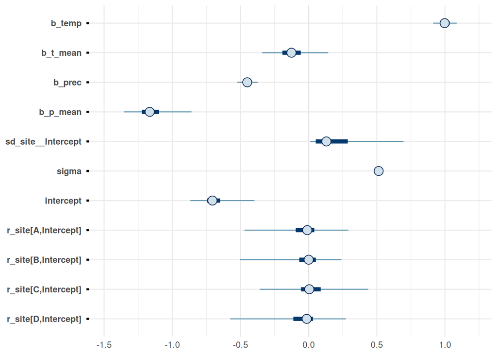

```r
mcmc_intervals(fit_mund_pos, pars = show)
```

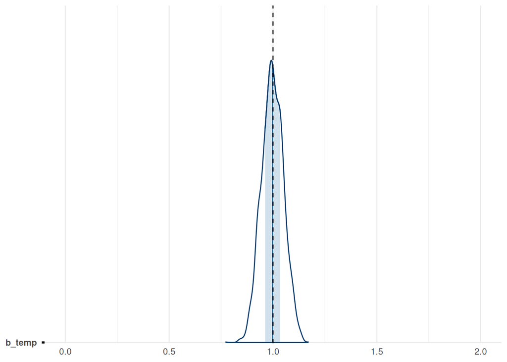

```r
fit_mund_pos |>
  coefplot(1, c(0, 2))
```

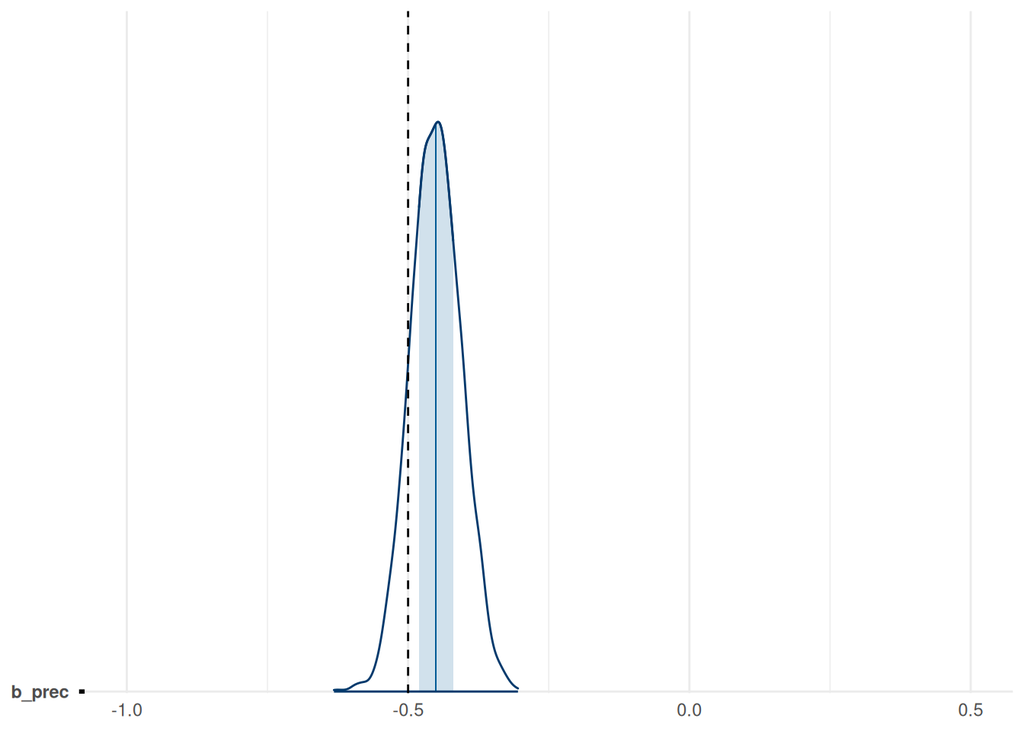

```r
fit_mund_pos |>
  coefplot(-0.5, c(-1, 0.5), pars = "b_prec")
```

```r
fit_mund_nul <- update(fit_mund_pos,
                       newdata = sim_nul,
                       file = "fits/sim/sim.mund.nul",
                       seed = 295)

fit_mund_nul
```

```
 Family: gaussian
  Links: mu = identity
Formula: FD ~ temp + t_mean + prec + p_mean + (1 | site)
   Data: sim_nul (Number of observations: 512)
  Draws: 4 chains, each with iter = 2000; warmup = 1000; thin = 1;
         total post-warmup draws = 4000

Multilevel Hyperparameters:
~site (Number of levels: 4)
              Estimate Est.Error l-95% CI u-95% CI Rhat Bulk_ESS Tail_ESS
sd(Intercept)     0.20      0.22     0.00     0.78 1.00      602     1200

Regression Coefficients:
          Estimate Est.Error l-95% CI u-95% CI Rhat Bulk_ESS Tail_ESS
Intercept    -0.37      0.18    -0.72     0.07 1.00     1449     1159
temp          0.00      0.05    -0.10     0.10 1.00     3756     3032
t_mean       -0.12      0.16    -0.41     0.25 1.00     1748     1005
prec         -0.45      0.04    -0.54    -0.37 1.00     3417     3118
p_mean       -1.15      0.16    -1.43    -0.75 1.00     1236      898

Further Distributional Parameters:
      Estimate Est.Error l-95% CI u-95% CI Rhat Bulk_ESS Tail_ESS
sigma     0.51      0.02     0.48     0.55 1.00     4313     3036

Draws were sampled using sample(hmc). For each parameter, Bulk_ESS
and Tail_ESS are effective sample size measures, and Rhat is the potential
scale reduction factor on split chains (at convergence, Rhat = 1).
```

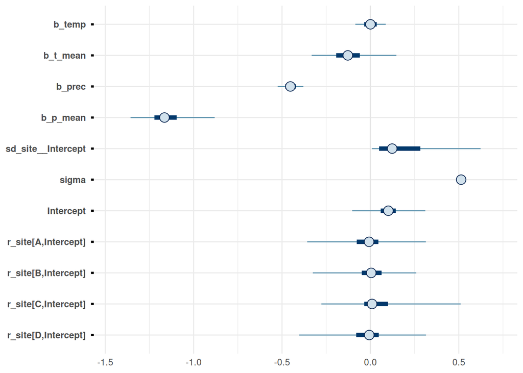

```r
mcmc_intervals(fit_mund_nul, pars = show)
```

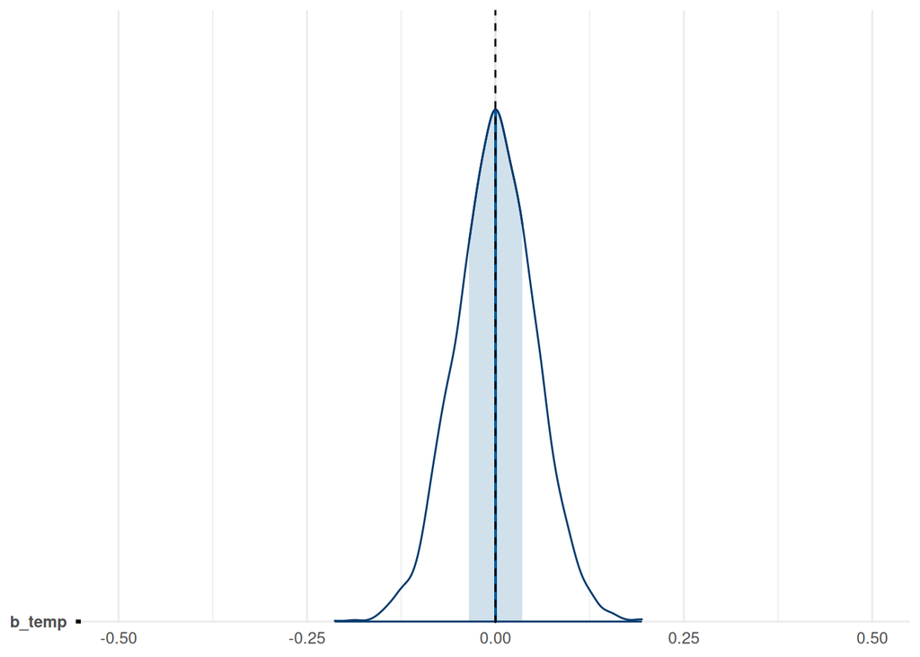

```r
fit_mund_nul |>
  coefplot(0, c(-0.5, 0.5))
```

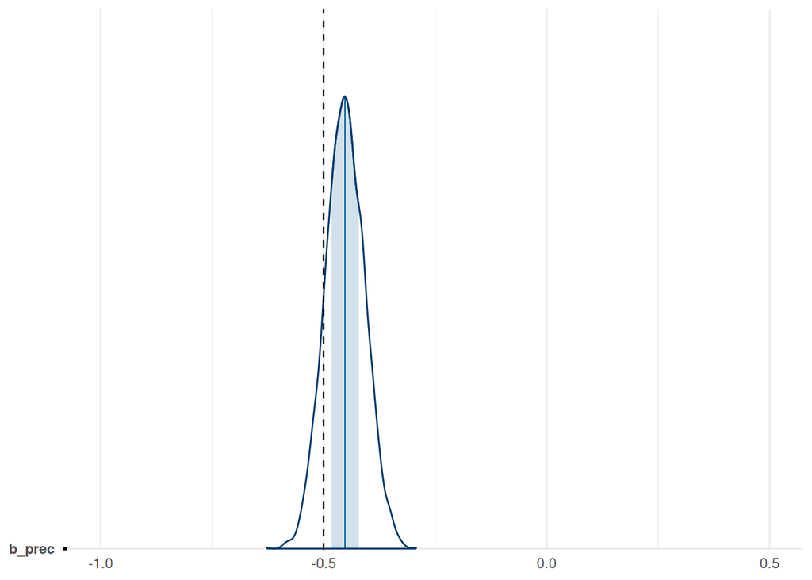

```r
fit_mund_nul |>
  coefplot(-0.5, c(-1, 0.5), pars = "b_prec")
```

```r
fit_mund_neg <- update(fit_mund_pos,
                       newdata = sim_neg,
                       file = "fits/sim/sim.mund.neg",
                       seed = 295)

fit_mund_neg
```

```
 Family: gaussian
  Links: mu = identity
Formula: FD ~ temp + t_mean + prec + p_mean + (1 | site)
   Data: sim_neg (Number of observations: 512)
  Draws: 4 chains, each with iter = 2000; warmup = 1000; thin = 1;
         total post-warmup draws = 4000

Multilevel Hyperparameters:
~site (Number of levels: 4)
              Estimate Est.Error l-95% CI u-95% CI Rhat Bulk_ESS Tail_ESS
sd(Intercept)     0.20      0.24     0.00     0.88 1.00      744     1000

Regression Coefficients:
          Estimate Est.Error l-95% CI u-95% CI Rhat Bulk_ESS Tail_ESS
Intercept    -0.41      0.21    -0.84     0.01 1.00     1458     1218
temp         -1.00      0.05    -1.10    -0.90 1.00     3470     2752
t_mean       -0.12      0.16    -0.43     0.29 1.00     1844     1079
prec         -0.45      0.04    -0.53    -0.36 1.00     3352     2738
p_mean       -1.16      0.16    -1.44    -0.74 1.00     1325     1035

Further Distributional Parameters:
      Estimate Est.Error l-95% CI u-95% CI Rhat Bulk_ESS Tail_ESS
sigma     0.51      0.02     0.48     0.55 1.00     3110     2672

Draws were sampled using sample(hmc). For each parameter, Bulk_ESS
and Tail_ESS are effective sample size measures, and Rhat is the potential
scale reduction factor on split chains (at convergence, Rhat = 1).
```

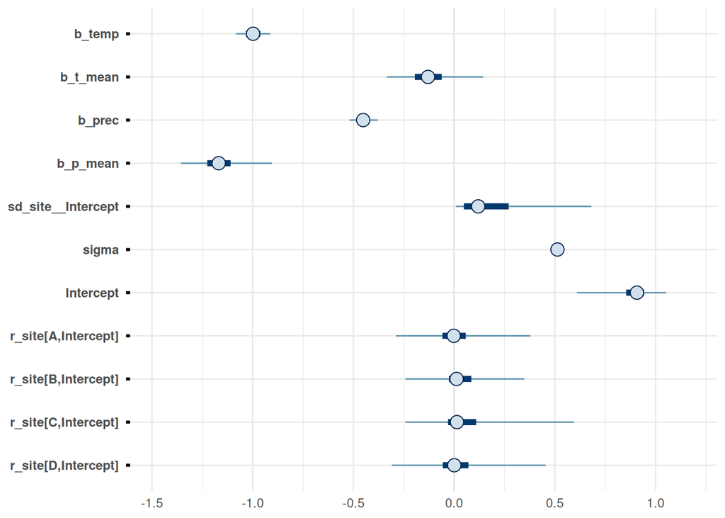

```r
mcmc_intervals(fit_mund_neg, pars = show)
```

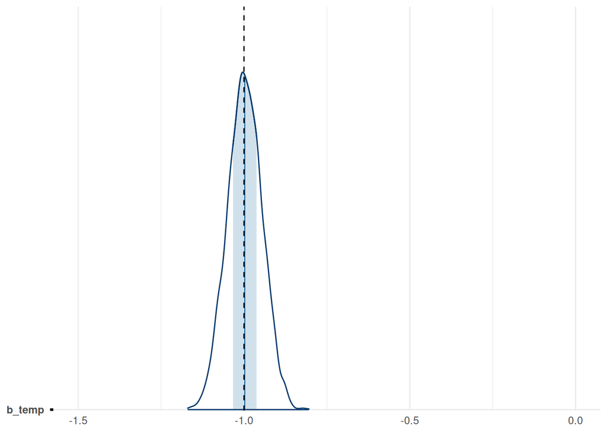

```r
fit_mund_neg |>
  coefplot(-1, c(-1.5, 0))
```

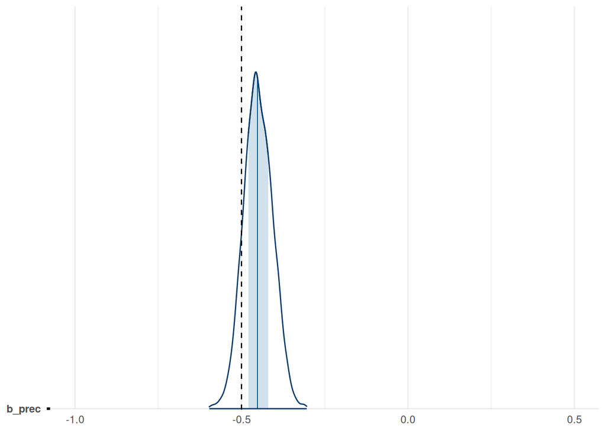

```r
fit_mund_neg |>
  coefplot(-0.5, c(-1, 0.5), pars = "b_prec")
```

## 5.5 Mean centering

This approach, similar to the contextual model, instead subtracts the mean from within-site predictor. The coefficients represent the between- and the within-site slopes.

```r
fit_cent_pos <- brm(FD ~ t_cent + t_mean + p_cent + p_mean + (1|site),
                    data = sim_pos,
                    prior = prior_re,
                    file = "fits/sim/sim.cent.pos",
                    seed = 295,
                    control = list(adapt_delta = 0.99))

fit_cent_pos
```

```
 Family: gaussian
  Links: mu = identity
Formula: FD ~ t_cent + t_mean + p_cent + p_mean + (1 | site)
   Data: sim_pos (Number of observations: 512)
  Draws: 4 chains, each with iter = 2000; warmup = 1000; thin = 1;
         total post-warmup draws = 4000

Multilevel Hyperparameters:
~site (Number of levels: 4)
              Estimate Est.Error l-95% CI u-95% CI Rhat Bulk_ESS Tail_ESS
sd(Intercept)     0.22      0.26     0.00     0.94 1.00      671      824

Regression Coefficients:
          Estimate Est.Error l-95% CI u-95% CI Rhat Bulk_ESS Tail_ESS
Intercept    -0.35      0.22    -0.72     0.20 1.00     1122     1045
t_cent        1.00      0.05     0.89     1.10 1.00     3506     2669
t_mean        0.85      0.17     0.46     1.20 1.00     1274      959
p_cent       -0.45      0.04    -0.53    -0.36 1.00     3972     2557
p_mean       -1.60      0.17    -1.89    -1.16 1.00     1218      986

Further Distributional Parameters:
      Estimate Est.Error l-95% CI u-95% CI Rhat Bulk_ESS Tail_ESS
sigma     0.51      0.02     0.48     0.55 1.00     3429     2622

Draws were sampled using sample(hmc). For each parameter, Bulk_ESS
and Tail_ESS are effective sample size measures, and Rhat is the potential
scale reduction factor on split chains (at convergence, Rhat = 1).
```

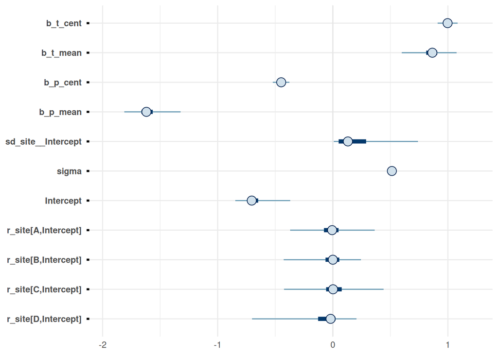

```r
mcmc_intervals(fit_cent_pos, pars = show)
```

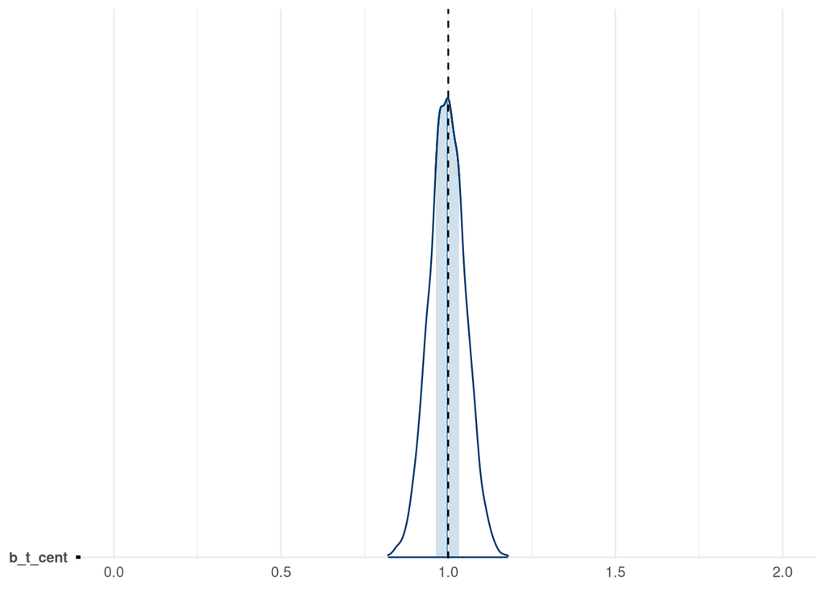

```r
fit_cent_pos |>
  coefplot(1, c(0, 2), "b_t_cent")
```

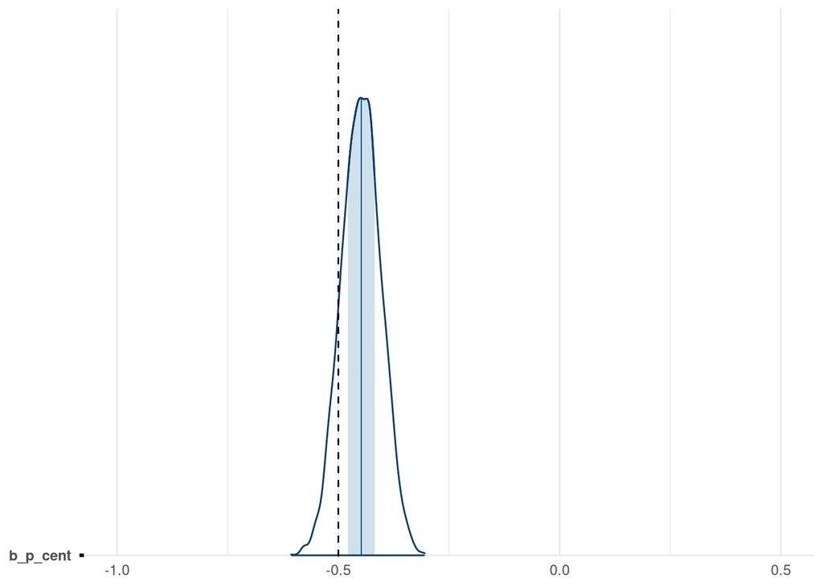

```r
fit_cent_pos |>
  coefplot(-0.5, c(-1, 0.5), "b_p_cent")
```

```r
fit_cent_nul <- update(fit_cent_pos,
                       newdata = sim_nul,
                       file = "fits/sim/sim.cent.nul",
                       seed = 295)

fit_cent_nul
```

```
 Family: gaussian
  Links: mu = identity
Formula: FD ~ t_cent + t_mean + p_cent + p_mean + (1 | site)
   Data: sim_nul (Number of observations: 512)
  Draws: 4 chains, each with iter = 2000; warmup = 1000; thin = 1;
         total post-warmup draws = 4000

Multilevel Hyperparameters:
~site (Number of levels: 4)
              Estimate Est.Error l-95% CI u-95% CI Rhat Bulk_ESS Tail_ESS
sd(Intercept)     0.21      0.25     0.01     0.90 1.01      593      839

Regression Coefficients:
          Estimate Est.Error l-95% CI u-95% CI Rhat Bulk_ESS Tail_ESS
Intercept    -0.37      0.22    -0.76     0.18 1.01     1546      967
t_cent        0.00      0.05    -0.10     0.10 1.00     4263     2952
t_mean       -0.12      0.17    -0.41     0.28 1.01     1423      875
p_cent       -0.45      0.04    -0.53    -0.36 1.00     3795     2657
p_mean       -1.60      0.17    -1.88    -1.17 1.00     1354      763

Further Distributional Parameters:
      Estimate Est.Error l-95% CI u-95% CI Rhat Bulk_ESS Tail_ESS
sigma     0.51      0.02     0.48     0.55 1.00     3755     2648

Draws were sampled using sample(hmc). For each parameter, Bulk_ESS
and Tail_ESS are effective sample size measures, and Rhat is the potential
scale reduction factor on split chains (at convergence, Rhat = 1).
```

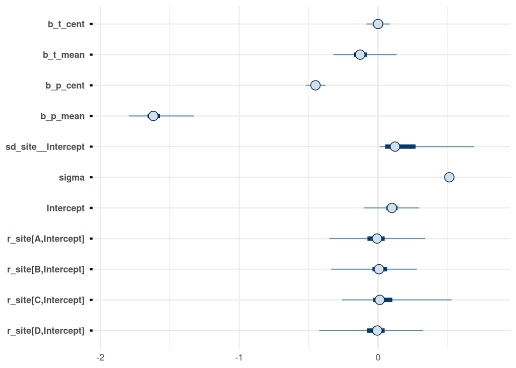

```r
mcmc_intervals(fit_cent_nul, pars = show)
```

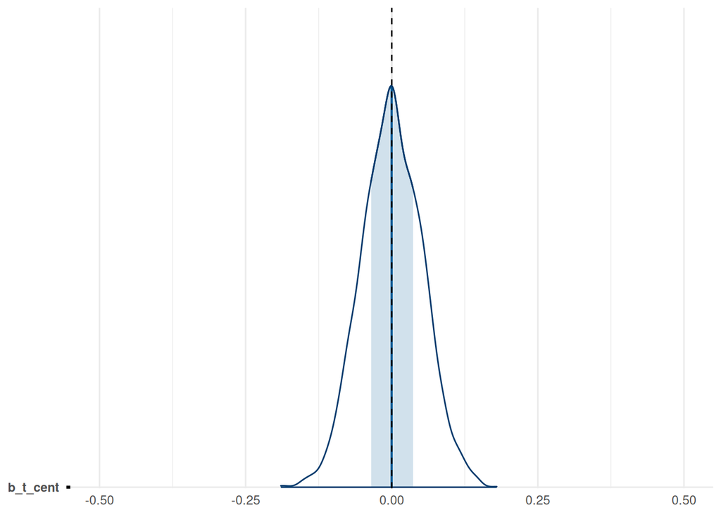

```r
fit_cent_nul |>
  coefplot(0, c(-0.5, 0.5), "b_t_cent")
```

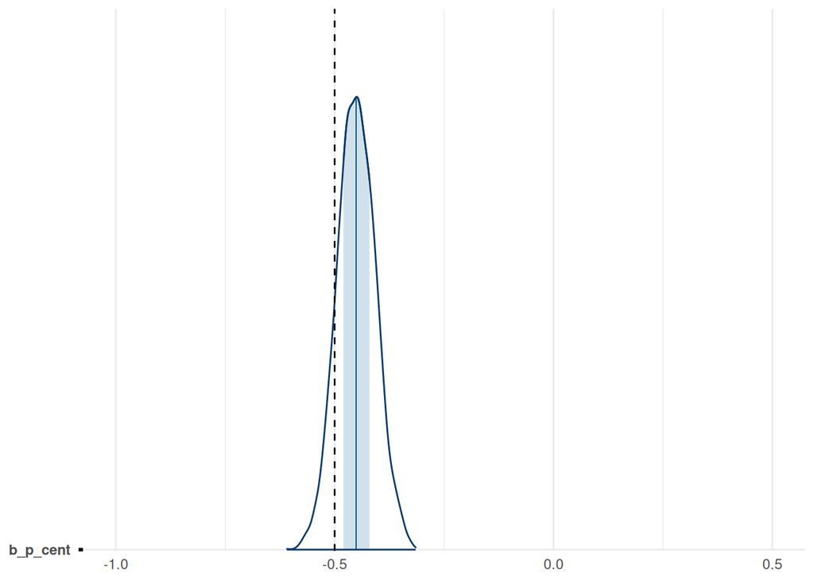

```r
fit_cent_nul |>
  coefplot(-0.5, c(-1, 0.5), "b_p_cent")
```

```r
fit_cent_neg <- update(fit_cent_pos,
                       newdata = sim_neg,
                       file = "fits/sim/sim.cent.neg",
                       seed = 295)

fit_cent_neg
```

```
 Family: gaussian
  Links: mu = identity
Formula: FD ~ t_cent + t_mean + p_cent + p_mean + (1 | site)
   Data: sim_neg (Number of observations: 512)
  Draws: 4 chains, each with iter = 2000; warmup = 1000; thin = 1;
         total post-warmup draws = 4000

Multilevel Hyperparameters:
~site (Number of levels: 4)
              Estimate Est.Error l-95% CI u-95% CI Rhat Bulk_ESS Tail_ESS
sd(Intercept)     0.25      0.32     0.00     1.08 1.00      584      814

Regression Coefficients:
          Estimate Est.Error l-95% CI u-95% CI Rhat Bulk_ESS Tail_ESS
Intercept    -0.36      0.25    -0.85     0.23 1.00     1406     1075
t_cent       -1.00      0.05    -1.11    -0.89 1.00     3726     2120
t_mean       -1.07      0.22    -1.34    -0.47 1.01     1352      943
p_cent       -0.45      0.04    -0.53    -0.36 1.00     3405     2734
p_mean       -1.56      0.22    -1.83    -0.91 1.00     1203      821

Further Distributional Parameters:
      Estimate Est.Error l-95% CI u-95% CI Rhat Bulk_ESS Tail_ESS
sigma     0.51      0.02     0.48     0.55 1.00     3594     2076

Draws were sampled using sample(hmc). For each parameter, Bulk_ESS
and Tail_ESS are effective sample size measures, and Rhat is the potential
scale reduction factor on split chains (at convergence, Rhat = 1).
```

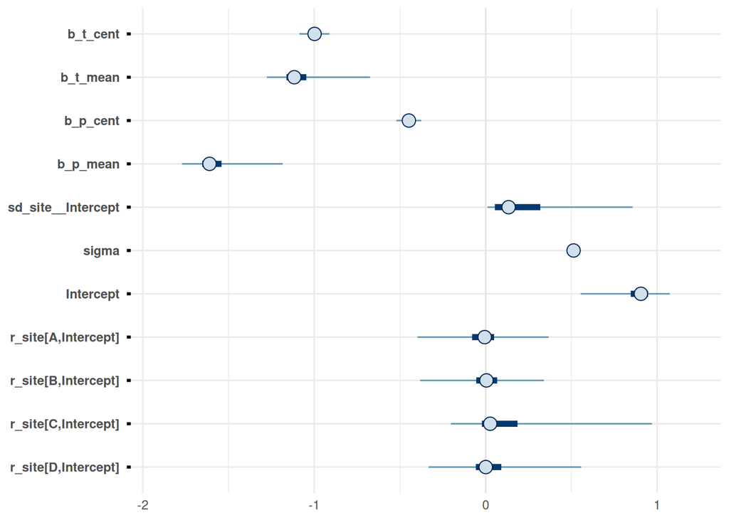

```r
mcmc_intervals(fit_cent_neg, pars = show)
```

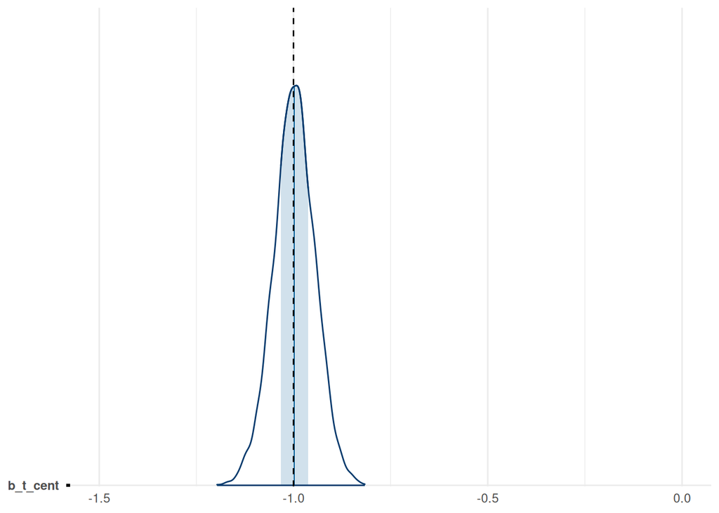

```r
fit_cent_neg |>
  coefplot(-1, c(-1.5, 0), "b_t_cent")
```

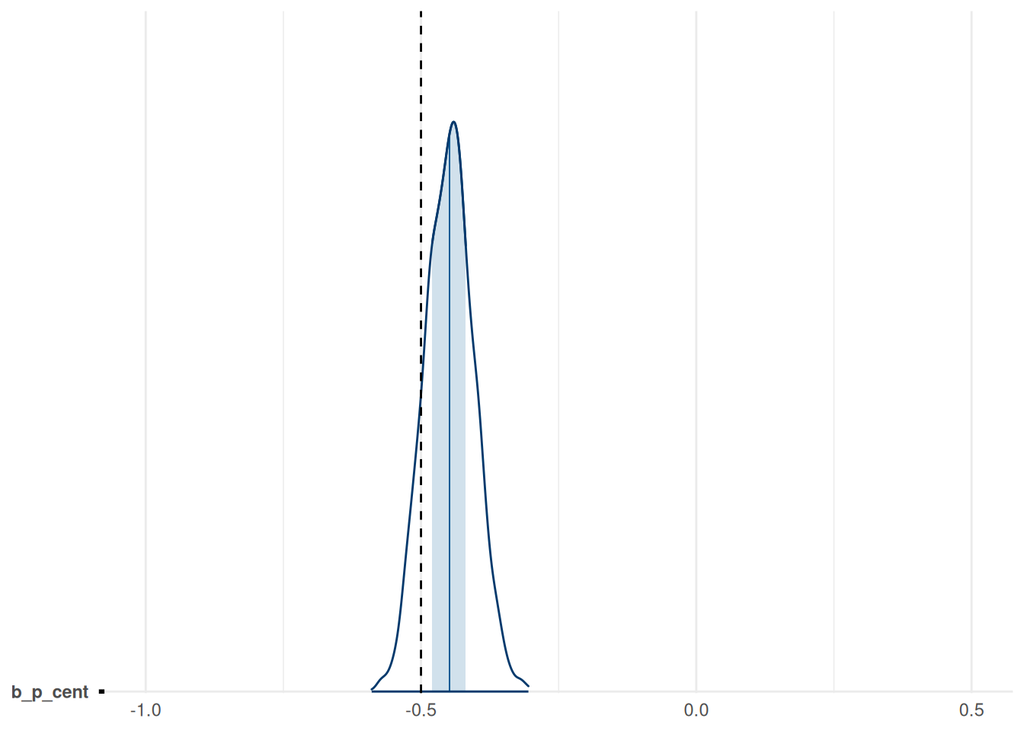

```r
fit_cent_neg |>
  coefplot(-0.5, c(-1, 0.5), "b_p_cent")
```

## 5.6 Latent Mundlak

The site-level means are not known. Using a latent mean approach instead of the empirical means respects this uncertainty. There is more than one way to implement this model in brms https://rubenarslan.github.io/posts/2023-03-11-latent-group-mean-centering-revisited https://vuorre.com/posts/latent-mean-centering/.

### 5.6.1 Measurement error

```r
sim_pos <- sim_pos |>
  mutate(temp_se = sd(temp)/sqrt(n()),
         prec_se = sd(prec)/sqrt(n()),
         .by = site)

sim_nul <- sim_nul |>
  mutate(temp_se = sd(temp)/sqrt(n()),
         prec_se = sd(prec)/sqrt(n()),
         .by = site)

sim_neg <- sim_neg |>
  mutate(temp_se = sd(temp)/sqrt(n()),
         prec_se = sd(prec)/sqrt(n()),
         .by = site)
```

We express the site mean as measured with error with the `me()` syntax:

```r
lat_formula_me <- bf(FD ~ me(t_mean, temp_se, gr = site) + temp +
                          me(p_mean, prec_se, gr = site) + prec + (1|site))

get_prior(lat_formula_me, data = sim_pos)
```

| prior | class | coef | group | resp | dpar | nlpar | lb | ub | tag | source |
| --- | --- | --- | --- | --- | --- | --- | --- | --- | --- | --- |
|  | b |  |  |  |  |  |  |  |  | default |
|  | b | mep_meanprec_segrEQsite |  |  |  |  |  |  |  | default |
|  | b | met_meantemp_segrEQsite |  |  |  |  |  |  |  | default |
|  | b | prec |  |  |  |  |  |  |  | default |
|  | b | temp |  |  |  |  |  |  |  | default |
| lkj(1) | corme |  |  |  |  |  |  |  |  | default |
|  | corme |  | site |  |  |  |  |  |  | default |
| student_t(3, -0.7, 4) | Intercept |  |  |  |  |  |  |  |  | default |
|  | meanme |  |  |  |  |  |  |  |  | default |
|  | meanme | mep_mean |  |  |  |  |  |  |  | default |
|  | meanme | met_mean |  |  |  |  |  |  |  | default |
| student_t(3, 0, 4) | sd |  |  |  |  |  | 0 |  |  | default |
|  | sd |  | site |  |  |  |  |  |  | default |
|  | sd | Intercept | site |  |  |  |  |  |  | default |
|  | sdme |  |  |  |  |  | 0 |  |  | default |
|  | sdme | mep_mean |  |  |  |  |  |  |  | default |
|  | sdme | met_mean |  |  |  |  |  |  |  | default |
| student_t(3, 0, 4) | sigma |  |  |  |  |  | 0 |  |  | default |

```r
lat_prior_me <- c(prior(student_t(3, 0, 0.7), class = "Intercept"),
                  prior(normal(0, 1), class = "b"),
                  prior(student_t(5, 0, 1), class = "sd", lb = 0),
                  prior(normal(0, 1), class = "sdme", lb = 0),
                  prior(student_t(5, 0, 1), class = "sigma", lb = 0))
```

```r
fit_lat_me_pos <- brm(lat_formula_me,
                      data = sim_pos,
                      prior = lat_prior_me,
                      file = "fits/sim/sim.lat.me.pos",
                      save_model = "fits/sim/sim.lat.me.pos.txt",
                      seed = 295,
                      control = list(adapt_delta = 0.9))

fit_lat_me_pos
```

```
 Family: gaussian
  Links: mu = identity
Formula: FD ~ me(t_mean, temp_se, gr = site) + temp + me(p_mean, prec_se, gr = site) + prec + (1 | site)
   Data: sim_pos (Number of observations: 512)
  Draws: 4 chains, each with iter = 2000; warmup = 1000; thin = 1;
         total post-warmup draws = 4000

Multilevel Hyperparameters:
~site (Number of levels: 4)
              Estimate Est.Error l-95% CI u-95% CI Rhat Bulk_ESS Tail_ESS
sd(Intercept)     0.42      0.46     0.01     1.63 1.00      751     1945

Regression Coefficients:
                        Estimate Est.Error l-95% CI u-95% CI Rhat Bulk_ESS
Intercept                  -0.18      0.39    -0.69     0.87 1.00     1058
temp                        0.99      0.05     0.89     1.10 1.00     5864
prec                       -0.45      0.04    -0.54    -0.37 1.00     5767
met_meantemp_segrEQsite    -0.02      0.28    -0.42     0.71 1.00     1353
mep_meanprec_segrEQsite    -1.03      0.31    -1.45    -0.15 1.00     1103
                        Tail_ESS
Intercept                   1591
temp                        2901
prec                        3129
met_meantemp_segrEQsite     1406
mep_meanprec_segrEQsite     1450

Further Distributional Parameters:
      Estimate Est.Error l-95% CI u-95% CI Rhat Bulk_ESS Tail_ESS
sigma     0.51      0.02     0.48     0.55 1.00     6084     2706

Draws were sampled using sample(hmc). For each parameter, Bulk_ESS
and Tail_ESS are effective sample size measures, and Rhat is the potential
scale reduction factor on split chains (at convergence, Rhat = 1).
```

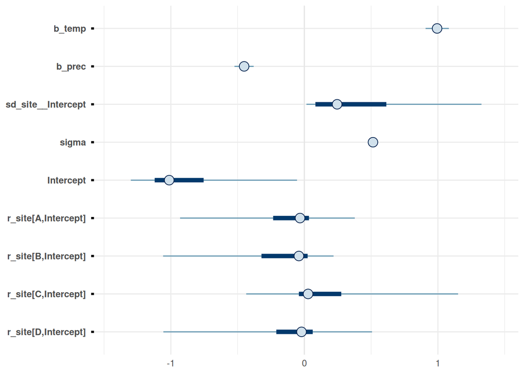

```r
mcmc_intervals(fit_lat_me_pos, pars = vars(!c(hide, matches("me"))))
```

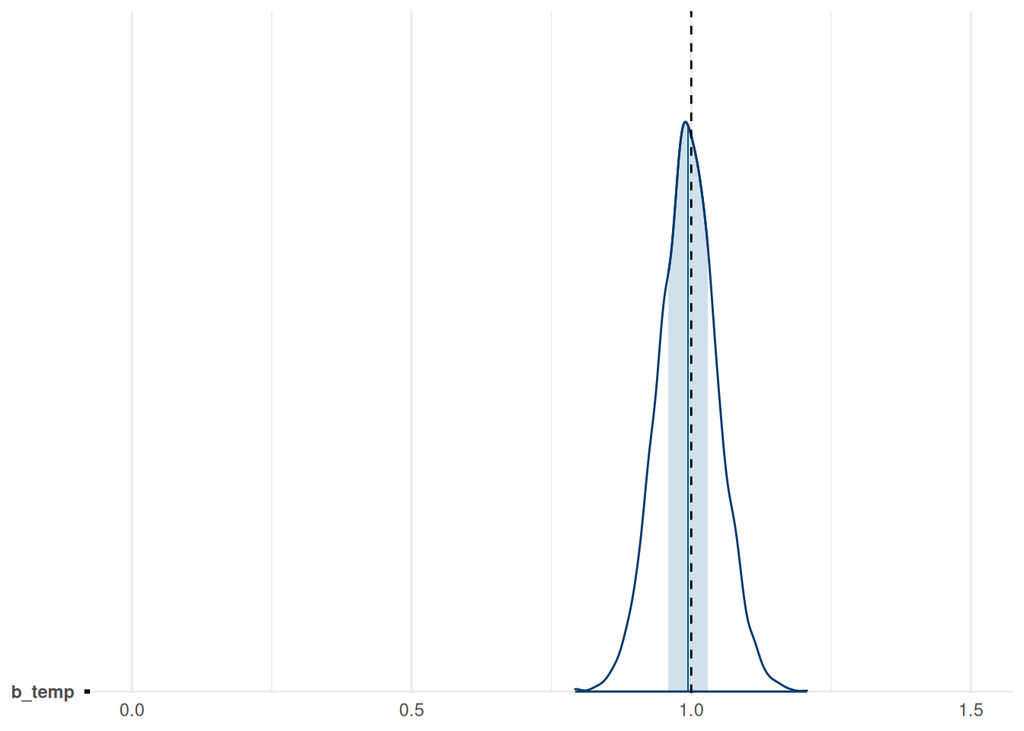

```r
fit_lat_me_pos |>
  coefplot(1, c(0, 1.5))
```

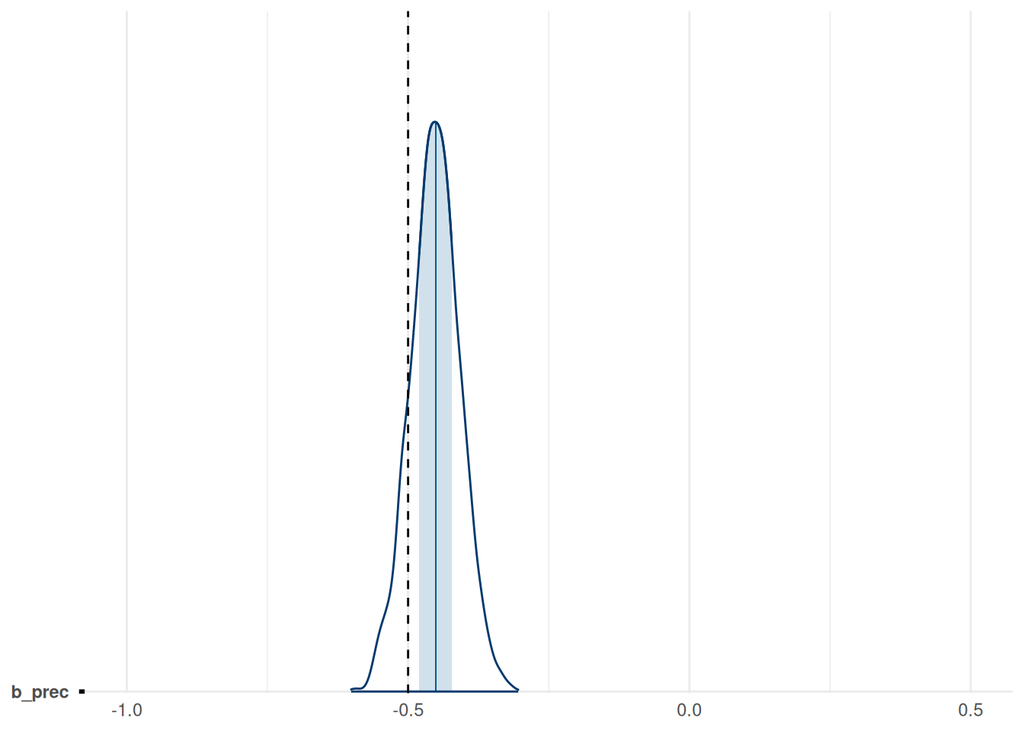

```r
fit_lat_me_pos |>
  coefplot(-0.5, c(-1, 0.5), "b_prec")
```

```r
fit_lat_me_nul <- update(fit_lat_me_pos,
                         newdata = sim_nul,
                         file = "fits/sim/sim.lat.me.nul",
                         seed = 295)

fit_lat_me_nul
```

```
 Family: gaussian
  Links: mu = identity
Formula: FD ~ me(t_mean, temp_se, gr = site) + temp + me(p_mean, prec_se, gr = site) + prec + (1 | site)
   Data: sim_nul (Number of observations: 512)
  Draws: 4 chains, each with iter = 2000; warmup = 1000; thin = 1;
         total post-warmup draws = 4000

Multilevel Hyperparameters:
~site (Number of levels: 4)
              Estimate Est.Error l-95% CI u-95% CI Rhat Bulk_ESS Tail_ESS
sd(Intercept)     0.32      0.37     0.01     1.35 1.01      747     1323

Regression Coefficients:
                        Estimate Est.Error l-95% CI u-95% CI Rhat Bulk_ESS
Intercept                  -0.32      0.26    -0.79     0.33 1.01     1398
temp                       -0.00      0.05    -0.10     0.10 1.00     5337
prec                       -0.45      0.04    -0.54    -0.37 1.00     5355
met_meantemp_segrEQsite    -0.08      0.24    -0.47     0.55 1.01     1180
mep_meanprec_segrEQsite    -1.11      0.25    -1.48    -0.42 1.01     1235
                        Tail_ESS
Intercept                   1202
temp                        2850
prec                        2788
met_meantemp_segrEQsite      721
mep_meanprec_segrEQsite      625

Further Distributional Parameters:
      Estimate Est.Error l-95% CI u-95% CI Rhat Bulk_ESS Tail_ESS
sigma     0.51      0.02     0.48     0.55 1.00     5235     2864

Draws were sampled using sample(hmc). For each parameter, Bulk_ESS
and Tail_ESS are effective sample size measures, and Rhat is the potential
scale reduction factor on split chains (at convergence, Rhat = 1).
```

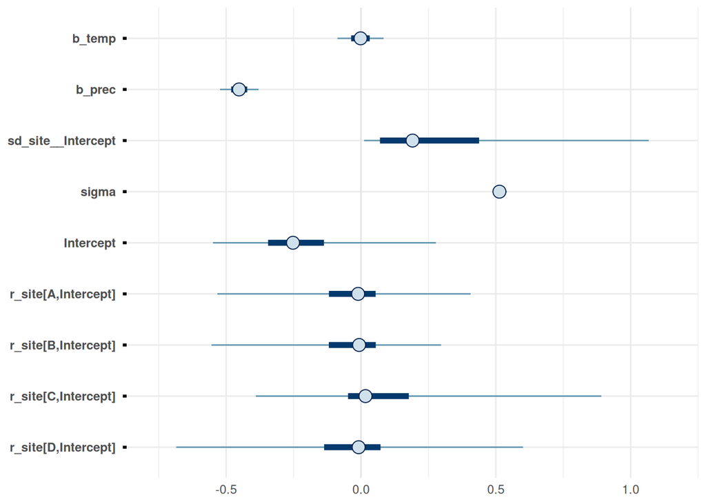

```r
mcmc_intervals(fit_lat_me_nul, pars = vars(!c(hide, matches("me"))))
```

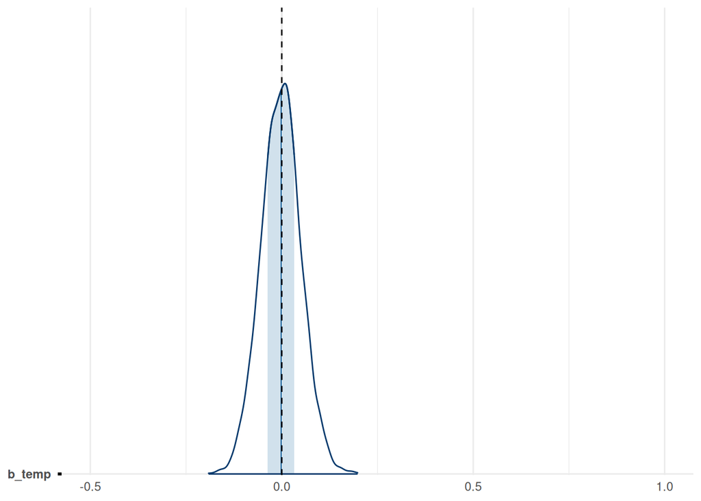

```r
fit_lat_me_nul |>
  coefplot(0, c(-0.5, 1))
```

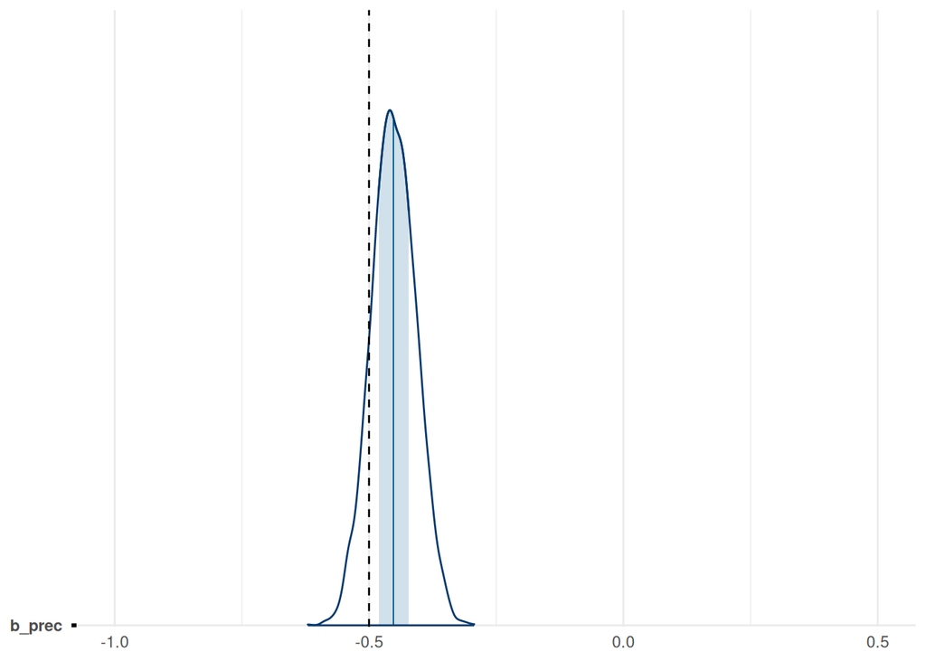

```r
fit_lat_me_nul |>
  coefplot(-0.5, c(-1, 0.5), "b_prec")
```

```r
fit_lat_me_neg <- update(fit_lat_me_pos,
                         newdata = sim_neg,
                         file = "fits/sim/sim.lat.me.neg",
                         seed = 295)

fit_lat_me_neg
```

```
 Family: gaussian
  Links: mu = identity
Formula: FD ~ me(t_mean, temp_se, gr = site) + temp + me(p_mean, prec_se, gr = site) + prec + (1 | site)
   Data: sim_neg (Number of observations: 512)
  Draws: 4 chains, each with iter = 2000; warmup = 1000; thin = 1;
         total post-warmup draws = 4000

Multilevel Hyperparameters:
~site (Number of levels: 4)
              Estimate Est.Error l-95% CI u-95% CI Rhat Bulk_ESS Tail_ESS
sd(Intercept)     0.31      0.36     0.01     1.31 1.00     1007     1629

Regression Coefficients:
                        Estimate Est.Error l-95% CI u-95% CI Rhat Bulk_ESS
Intercept                  -0.42      0.26    -1.01     0.13 1.00     1934
temp                       -1.00      0.05    -1.09    -0.90 1.00     4486
prec                       -0.45      0.04    -0.53    -0.37 1.00     5113
met_meantemp_segrEQsite    -0.13      0.21    -0.59     0.37 1.00     2040
mep_meanprec_segrEQsite    -1.16      0.22    -1.57    -0.66 1.00     1725
                        Tail_ESS
Intercept                   1514
temp                        2771
prec                        3077
met_meantemp_segrEQsite     1686
mep_meanprec_segrEQsite     1464

Further Distributional Parameters:
      Estimate Est.Error l-95% CI u-95% CI Rhat Bulk_ESS Tail_ESS
sigma     0.51      0.02     0.49     0.55 1.00     5137     2906

Draws were sampled using sample(hmc). For each parameter, Bulk_ESS
and Tail_ESS are effective sample size measures, and Rhat is the potential
scale reduction factor on split chains (at convergence, Rhat = 1).
```

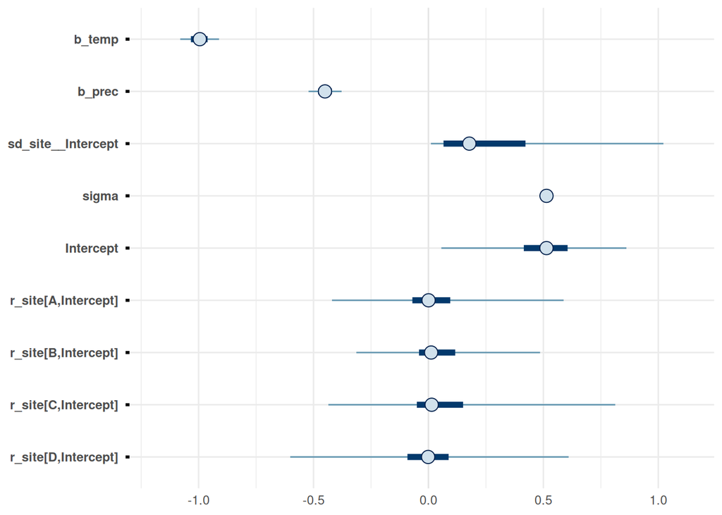

```r
mcmc_intervals(fit_lat_me_neg, pars = vars(!c(hide, matches("me"))))
```

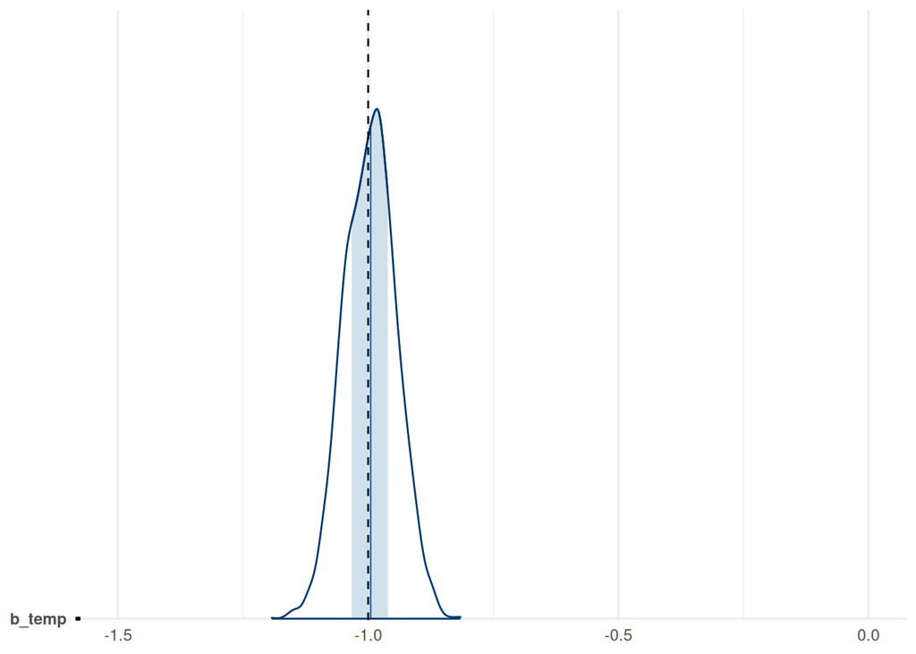

```r
fit_lat_me_neg |>
  coefplot(-1, c(-1.5, 0))
```

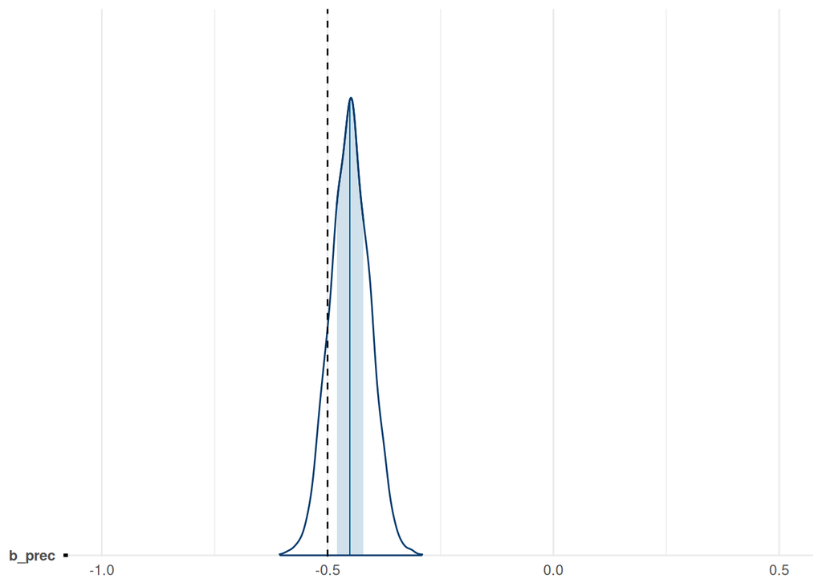

```r
fit_lat_me_neg |>
  coefplot(-0.5, c(-1, 0.5), "b_prec")
```

Closer inspection of the Stan code for the models above reveals they might not be grouping the latent mean by site. This might be the main reason they differ from the ones below.

### 5.6.2 Missingness

We duplicate the weather variable, then use the `mi()` notation, which is now favored over `me()`.

```r
sim_pos <- sim_pos |>
  mutate(temp2 = temp,
         prec2 = prec)

sim_nul <- sim_nul |>
  mutate(temp2 = temp,
         prec2 = prec)

sim_neg <- sim_neg |>
  mutate(temp2 = temp,
         prec2 = prec)

lat_formula_mi <- bf(FD ~ (1|site) + temp + mi(temp2) + prec + mi(prec2)) +
                  bf(temp2 | mi(temp_se) ~ (1|site)) +
                  bf(prec2 | mi(prec_se) ~ (1|site))

get_prior(lat_formula_mi, data = sim_pos)
```

| prior | class | coef | group | resp | dpar | nlpar | lb | ub | tag | source |
| --- | --- | --- | --- | --- | --- | --- | --- | --- | --- | --- |
|  | b |  |  | FD |  |  |  |  |  | default |
|  | b | miprec2 |  | FD |  |  |  |  |  | default |
|  | b | mitemp2 |  | FD |  |  |  |  |  | default |
|  | b | prec |  | FD |  |  |  |  |  | default |
|  | b | temp |  | FD |  |  |  |  |  | default |
| student_t(3, -0.7, 4) | Intercept |  |  | FD |  |  |  |  |  | default |
| student_t(3, 0, 4) | sd |  |  | FD |  |  | 0 |  |  | default |
|  | sd |  | site | FD |  |  |  |  |  | default |
|  | sd | Intercept | site | FD |  |  |  |  |  | default |
| student_t(3, 0, 4) | sigma |  |  | FD |  |  | 0 |  |  | default |
| student_t(3, -0.2, 2.5) | Intercept |  |  | prec2 |  |  |  |  |  | default |
| student_t(3, 0, 2.5) | sd |  |  | prec2 |  |  | 0 |  |  | default |
|  | sd |  | site | prec2 |  |  |  |  |  | default |
|  | sd | Intercept | site | prec2 |  |  |  |  |  | default |
| student_t(3, 0, 2.5) | sigma |  |  | prec2 |  |  | 0 |  |  | default |
| student_t(3, -0.6, 2.5) | Intercept |  |  | temp2 |  |  |  |  |  | default |
| student_t(3, 0, 2.5) | sd |  |  | temp2 |  |  | 0 |  |  | default |
|  | sd |  | site | temp2 |  |  |  |  |  | default |
|  | sd | Intercept | site | temp2 |  |  |  |  |  | default |
| student_t(3, 0, 2.5) | sigma |  |  | temp2 |  |  | 0 |  |  | default |

```r
lat_prior_mi <- c(prior(student_t(3, 0, 0.7), class = "Intercept", resp = "FD"),
                  prior(normal(0, 1), class = "b", resp = "FD"),
                  prior(student_t(3, 0, 0.5), class = "sd", lb = 0, resp = "FD"),
                  prior(student_t(3, 0, 0.5), class = "sigma", lb = 0, resp = "FD"),
                  prior(student_t(3, 0, 1), class = "sd", lb = 0, resp = "temp2"),
                  prior(student_t(3, 0, 0.5), class = "sigma", lb = 0, resp = "temp2"),
                  prior(student_t(3, 0, 1), class = "sd", lb = 0, resp = "prec2"),
                  prior(student_t(3, 0, 0.5), class = "sigma", lb = 0, resp = "prec2"))
```

```r
fit_lat_mi_pos <- brm(lat_formula_mi,
                      data = sim_pos,
                      prior = lat_prior_mi,
                      file = "fits/sim/sim.lat.mi.pos",
                      save_model = "fits/sim/sim.lat.mi.pos.txt",
                      seed = 295,
                      control = list(adapt_delta = 0.9))

fit_lat_mi_pos
```

```
 Family: MV(gaussian, gaussian, gaussian)
  Links: mu = identity
         mu = identity
         mu = identity
Formula: FD ~ (1 | site) + temp + mi(temp2) + prec + mi(prec2)
         temp2 | mi(temp_se) ~ (1 | site)
         prec2 | mi(prec_se) ~ (1 | site)
   Data: sim_pos (Number of observations: 512)
  Draws: 4 chains, each with iter = 2000; warmup = 1000; thin = 1;
         total post-warmup draws = 4000

Multilevel Hyperparameters:
~site (Number of levels: 4)
                    Estimate Est.Error l-95% CI u-95% CI Rhat Bulk_ESS Tail_ESS
sd(FD_Intercept)        1.33      0.46     0.73     2.51 1.00     1599     2341
sd(temp2_Intercept)     1.45      0.57     0.73     2.96 1.00     1664     1942
sd(prec2_Intercept)     1.45      0.56     0.75     2.87 1.00     1709     2104

Regression Coefficients:
                Estimate Est.Error l-95% CI u-95% CI Rhat Bulk_ESS Tail_ESS
FD_Intercept        0.28      0.53    -0.76     1.39 1.00     1255     1857
temp2_Intercept    -0.64      0.72    -2.10     0.77 1.00     1083     1505
prec2_Intercept    -0.45      0.68    -1.81     0.97 1.00     1339     1944
FD_temp             0.49      0.59    -0.71     1.61 1.00     1305     1822
FD_prec            -0.25      0.68    -1.55     1.13 1.00     1144     2075
FD_mitemp2          0.53      0.59    -0.62     1.73 1.00     1302     1944
FD_miprec2         -0.21      0.69    -1.60     1.10 1.00     1139     2046

Further Distributional Parameters:
            Estimate Est.Error l-95% CI u-95% CI Rhat Bulk_ESS Tail_ESS
sigma_FD        0.51      0.02     0.48     0.55 1.00     5614     2869
sigma_temp2     0.44      0.01     0.41     0.47 1.00     5659     2427
sigma_prec2     0.51      0.02     0.48     0.55 1.00     4538     2813

Draws were sampled using sample(hmc). For each parameter, Bulk_ESS
and Tail_ESS are effective sample size measures, and Rhat is the potential
scale reduction factor on split chains (at convergence, Rhat = 1).
```

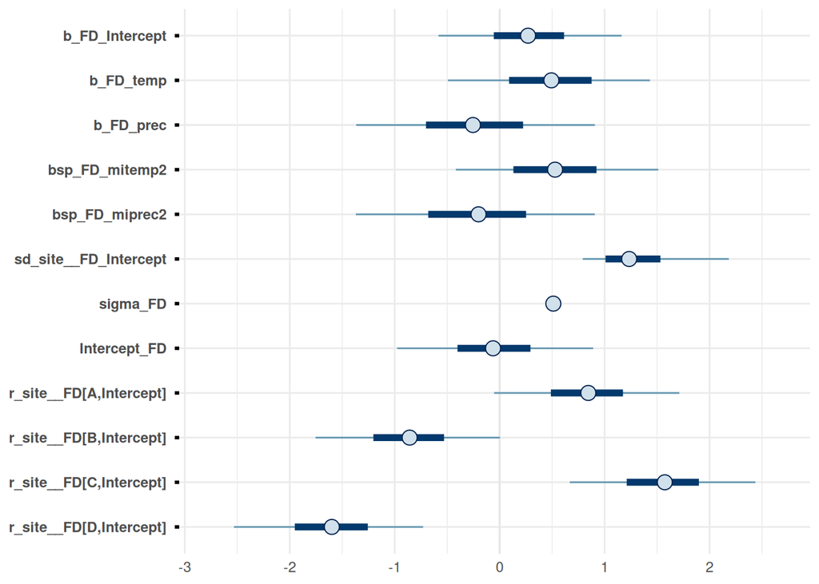

```r
mcmc_intervals(fit_lat_mi_pos, pars = vars(matches("_FD")))
```

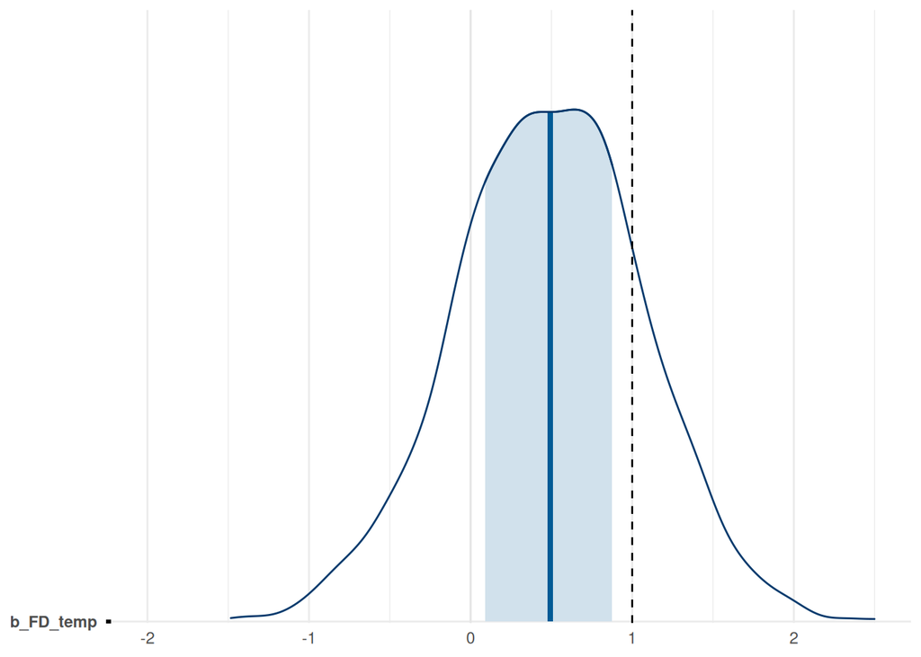

```r
fit_lat_mi_pos |>
  coefplot(1, c(-2, 2.5), "b_FD_temp")
```

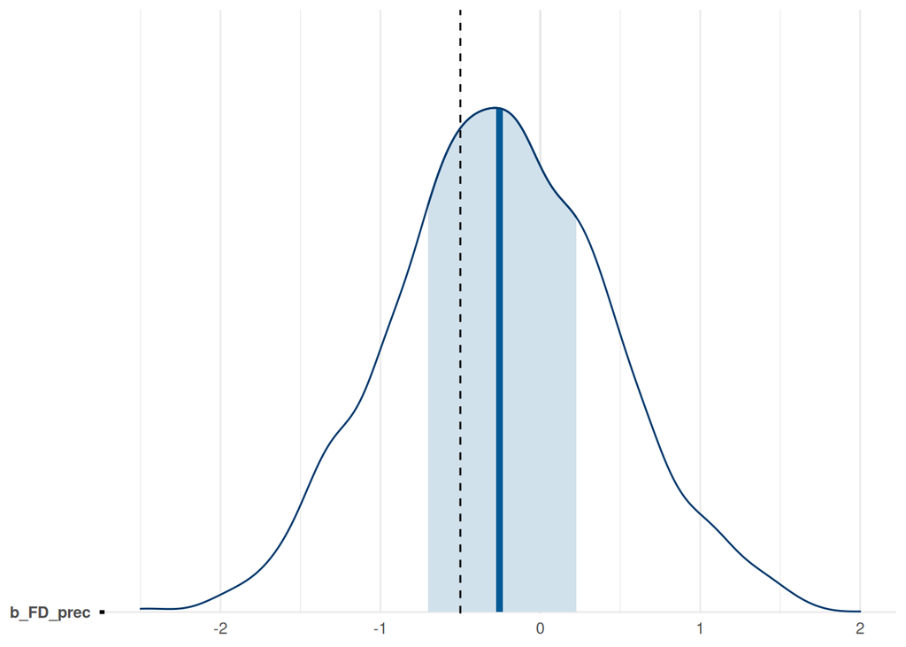

```r
fit_lat_mi_pos |>
  coefplot(-0.5, c(-2.5, 2), "b_FD_prec")
```

```r
fit_lat_mi_nul <- update(fit_lat_mi_pos,
                         newdata = sim_nul,
                         file = "fits/sim/sim.lat.mi.nul",
                         seed = 295)

fit_lat_mi_nul
```

```
 Family: MV(gaussian, gaussian, gaussian)
  Links: mu = identity
         mu = identity
         mu = identity
Formula: FD ~ (1 | site) + temp + mi(temp2) + prec + mi(prec2)
         temp2 | mi(temp_se) ~ (1 | site)
         prec2 | mi(prec_se) ~ (1 | site)
   Data: sim_nul (Number of observations: 512)
  Draws: 4 chains, each with iter = 2000; warmup = 1000; thin = 1;
         total post-warmup draws = 4000

Multilevel Hyperparameters:
~site (Number of levels: 4)
                    Estimate Est.Error l-95% CI u-95% CI Rhat Bulk_ESS Tail_ESS
sd(FD_Intercept)        1.32      0.45     0.75     2.45 1.00     1739     2284
sd(temp2_Intercept)     1.44      0.57     0.74     2.96 1.00     1895     2050
sd(prec2_Intercept)     1.46      0.58     0.76     2.94 1.00     1519     1815

Regression Coefficients:
                Estimate Est.Error l-95% CI u-95% CI Rhat Bulk_ESS Tail_ESS
FD_Intercept        0.16      0.53    -0.91     1.19 1.00     1072     1645
temp2_Intercept    -0.64      0.72    -2.06     0.71 1.00     1222     1637
prec2_Intercept    -0.46      0.72    -1.86     0.98 1.00     1221     1469
FD_temp             0.09      0.59    -1.12     1.28 1.00     1312     2084
FD_prec            -0.20      0.71    -1.55     1.19 1.00     1187     1833
FD_mitemp2         -0.09      0.60    -1.26     1.11 1.00     1312     2007
FD_miprec2         -0.26      0.72    -1.67     1.11 1.00     1184     1827

Further Distributional Parameters:
            Estimate Est.Error l-95% CI u-95% CI Rhat Bulk_ESS Tail_ESS
sigma_FD        0.51      0.02     0.48     0.54 1.00     5366     2874
sigma_temp2     0.44      0.01     0.41     0.47 1.00     6041     3246
sigma_prec2     0.51      0.02     0.48     0.55 1.00     5847     2884

Draws were sampled using sample(hmc). For each parameter, Bulk_ESS
and Tail_ESS are effective sample size measures, and Rhat is the potential
scale reduction factor on split chains (at convergence, Rhat = 1).
```

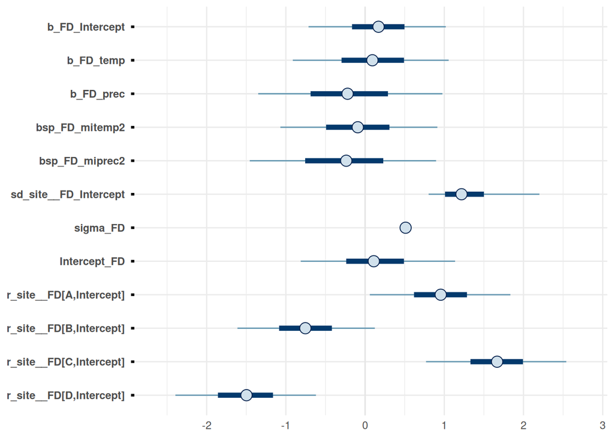

```r
mcmc_intervals(fit_lat_mi_nul, pars = vars(matches("_FD")))
```

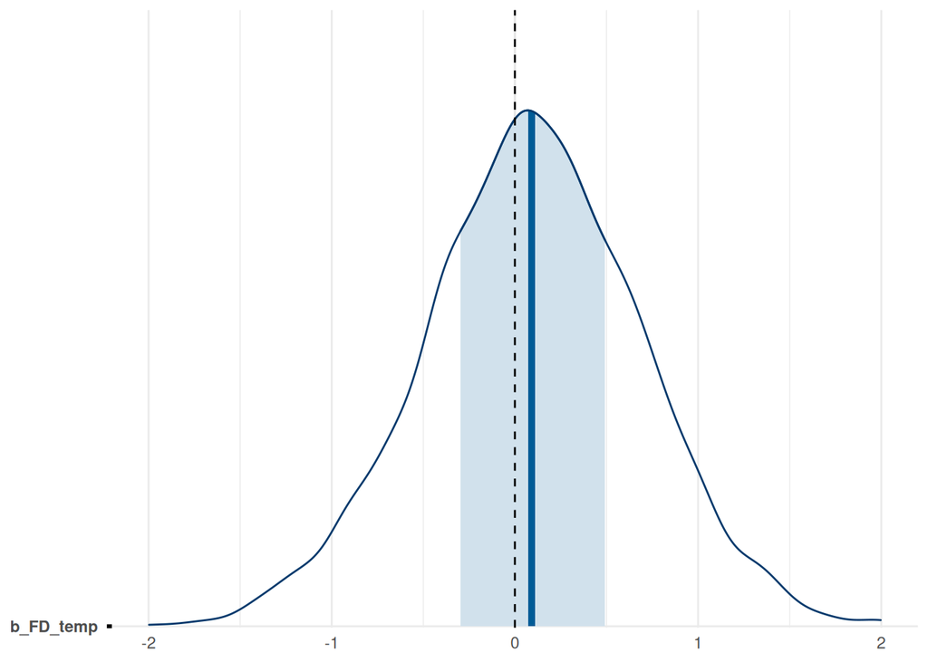

```r
fit_lat_mi_nul |>
  coefplot(0, c(-2, 2), "b_FD_temp")
```

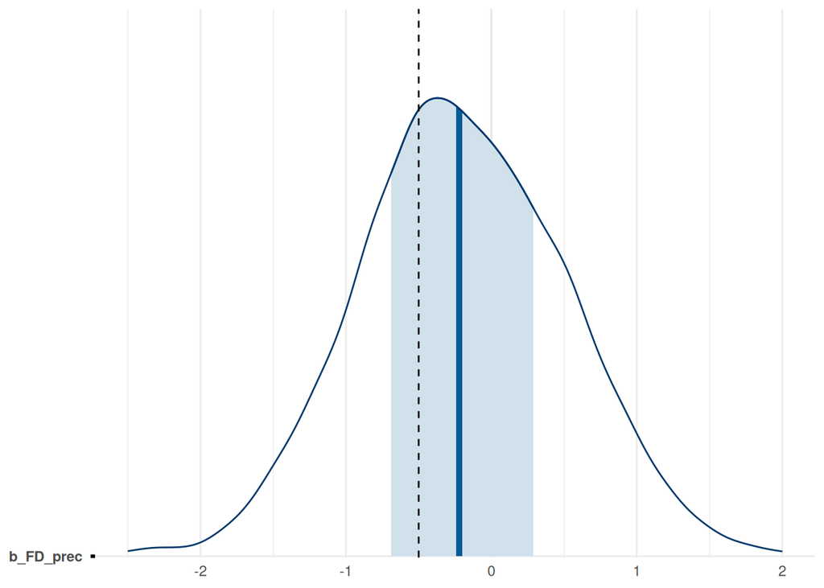

```r
fit_lat_mi_nul |>
  coefplot(-0.5, c(-2.5, 2), "b_FD_prec")
```

```r
fit_lat_mi_neg <- update(fit_lat_mi_pos,
                         newdata = sim_neg,
                         file = "fits/sim/sim.lat.mi.neg",
                         seed = 295)

fit_lat_mi_neg
```

```
 Family: MV(gaussian, gaussian, gaussian)
  Links: mu = identity
         mu = identity
         mu = identity
Formula: FD ~ (1 | site) + temp + mi(temp2) + prec + mi(prec2)
         temp2 | mi(temp_se) ~ (1 | site)
         prec2 | mi(prec_se) ~ (1 | site)
   Data: sim_neg (Number of observations: 512)
  Draws: 4 chains, each with iter = 2000; warmup = 1000; thin = 1;
         total post-warmup draws = 4000

Multilevel Hyperparameters:
~site (Number of levels: 4)
                    Estimate Est.Error l-95% CI u-95% CI Rhat Bulk_ESS Tail_ESS
sd(FD_Intercept)        1.33      0.47     0.74     2.55 1.00     1609     2512
sd(temp2_Intercept)     1.47      0.59     0.74     2.99 1.00     1825     2262
sd(prec2_Intercept)     1.46      0.57     0.75     2.95 1.00     2097     2462

Regression Coefficients:
                Estimate Est.Error l-95% CI u-95% CI Rhat Bulk_ESS Tail_ESS
FD_Intercept        0.03      0.55    -1.10     1.08 1.00     1304     2029
temp2_Intercept    -0.62      0.73    -2.14     0.87 1.00     1055     1538
prec2_Intercept    -0.44      0.69    -1.84     0.91 1.00     1270     2112
FD_temp            -0.30      0.62    -1.53     0.87 1.00     1294     1674
FD_prec            -0.18      0.70    -1.55     1.20 1.00     1055     1592
FD_mitemp2         -0.70      0.63    -1.86     0.53 1.00     1290     1711
FD_miprec2         -0.28      0.71    -1.68     1.10 1.00     1043     1523

Further Distributional Parameters:
            Estimate Est.Error l-95% CI u-95% CI Rhat Bulk_ESS Tail_ESS
sigma_FD        0.51      0.02     0.48     0.54 1.00     5470     2954
sigma_temp2     0.44      0.01     0.41     0.47 1.00     5944     2839
sigma_prec2     0.51      0.02     0.48     0.55 1.00     5847     3107

Draws were sampled using sample(hmc). For each parameter, Bulk_ESS
and Tail_ESS are effective sample size measures, and Rhat is the potential
scale reduction factor on split chains (at convergence, Rhat = 1).
```

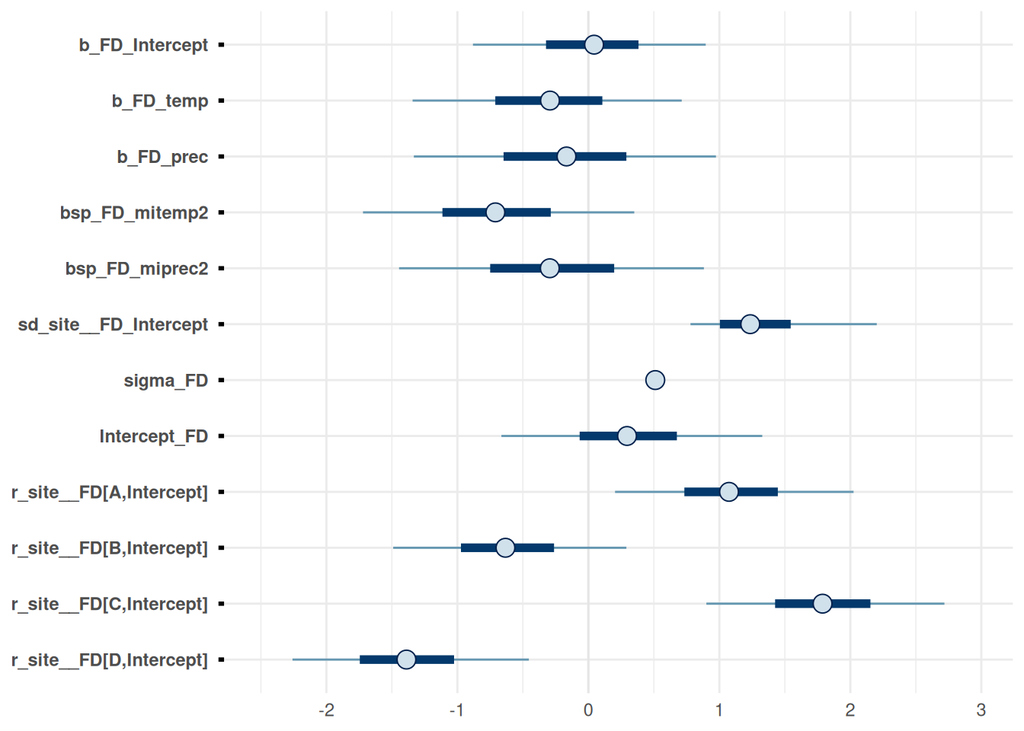

```r
mcmc_intervals(fit_lat_mi_neg, pars = vars(matches("_FD")))
```

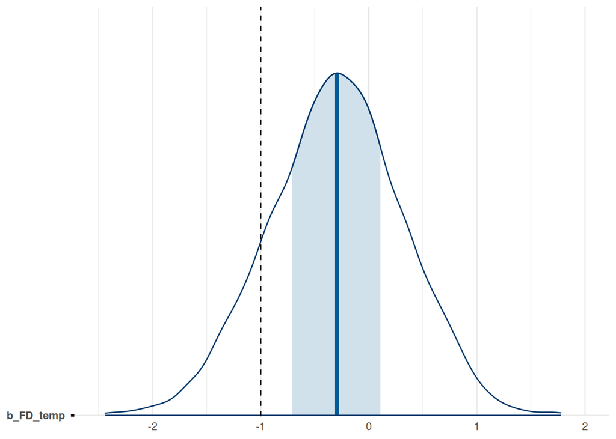

```r
fit_lat_mi_neg |>
  coefplot(-1, c(-2.5, 2), "b_FD_temp")
```

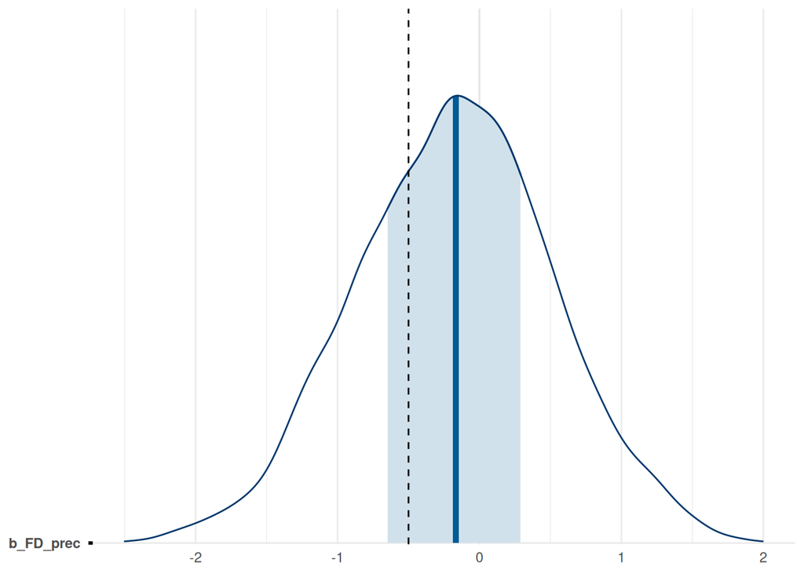

```r
fit_lat_mi_neg |>
  coefplot(-0.5, c(-2.5, 2), "b_FD_prec")
```

## 5.7 Model comparison

The following visualization is inspired by Ruben Arslan’s [post](https://rubenarslan.github.io/posts/2023-03-11-latent-group-mean-centering-revisited).

The temperature coefficients:

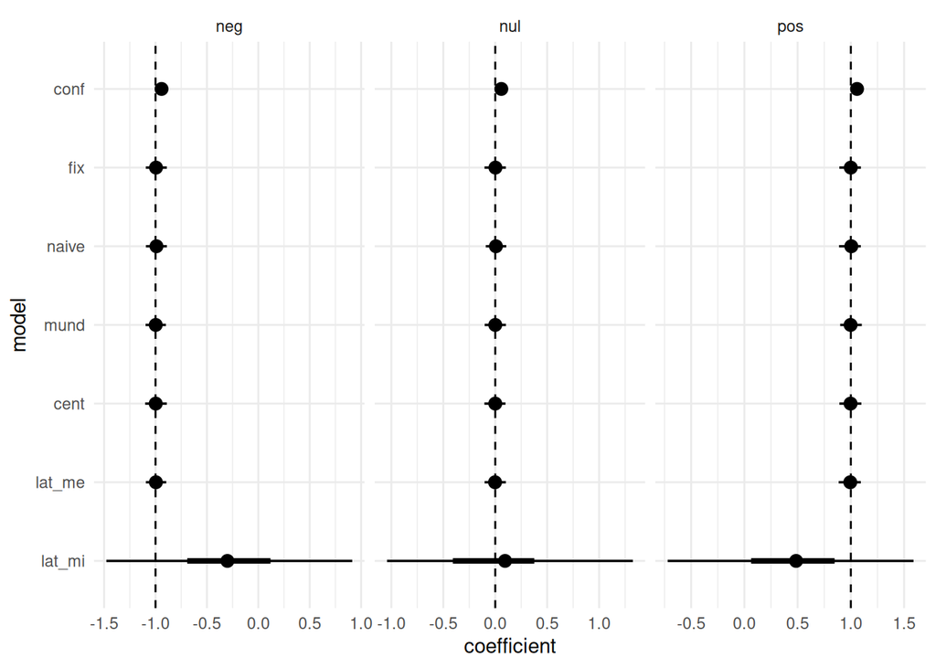

```r
summary_t <- bind_rows(lst(
          gather_draws(fit_conf_pos, b_temp),
          gather_draws(fit_fix_pos, b_temp),
          gather_draws(fit_naive_pos, b_temp),
          gather_draws(fit_mund_pos, b_temp),
          gather_draws(fit_cent_pos, b_t_cent),
          gather_draws(fit_lat_me_pos, b_temp),
          gather_draws(fit_lat_mi_pos, b_FD_temp),
          gather_draws(fit_conf_nul, b_temp),
          gather_draws(fit_fix_nul, b_temp),
          gather_draws(fit_naive_nul, b_temp),
          gather_draws(fit_mund_nul, b_temp),
          gather_draws(fit_cent_nul, b_t_cent),
          gather_draws(fit_lat_me_nul, b_temp),
          gather_draws(fit_lat_mi_nul, b_FD_temp),
          gather_draws(fit_conf_neg, b_temp),
          gather_draws(fit_fix_neg, b_temp),
          gather_draws(fit_naive_neg, b_temp),
          gather_draws(fit_mund_neg, b_temp),
          gather_draws(fit_cent_neg, b_t_cent),
          gather_draws(fit_lat_me_neg, b_temp),
          gather_draws(fit_lat_mi_neg, b_FD_temp)
          ),
          .id = "model") |>
  ungroup() |>
  mutate(model = str_remove_all(model, "gather_draws|\\(|\\)")) |>
  mutate(effect = str_extract(model, "(?<=_)[^_,]+(?=,|$)"),
         model = str_extract(model, "(?<=_).*(?=,)")) |>
  mutate(model = str_extract(model, ".*(?=_)")) |>
  mutate(model = as_factor(model)) |>
  group_by(model, effect, .variable) |>
  mean_hdci(.width = c(0.5, 0.95))

trueline <- tibble(x = -1:1,
                   effect = c("neg", "nul", "pos"))

summary_t |>
  ggplot(aes(y = model, x = .value, xmin = .lower, xmax = .upper)) +
  geom_pointinterval() +
  scale_y_discrete(limits = rev(levels(summary_t$model))) +
  geom_vline(aes(xintercept = x), linetype = 2, data = trueline) +
  facet_wrap(~ effect, scales = "free_x") +
  labs(x = "coefficient")
```

The precipitation coefficients:

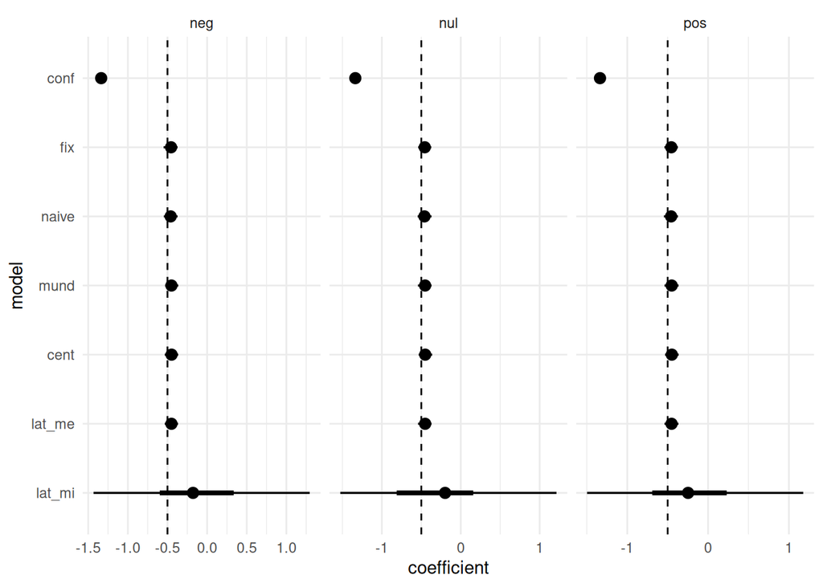

```r
summary_p <- bind_rows(lst(
          gather_draws(fit_conf_pos, b_prec),
          gather_draws(fit_fix_pos, b_prec),
          gather_draws(fit_naive_pos, b_prec),
          gather_draws(fit_mund_pos, b_prec),
          gather_draws(fit_cent_pos, b_p_cent),
          gather_draws(fit_lat_me_pos, b_prec),
          gather_draws(fit_lat_mi_pos, b_FD_prec),
          gather_draws(fit_conf_nul, b_prec),
          gather_draws(fit_fix_nul, b_prec),
          gather_draws(fit_naive_nul, b_prec),
          gather_draws(fit_mund_nul, b_prec),
          gather_draws(fit_cent_nul, b_p_cent),
          gather_draws(fit_lat_me_nul, b_prec),
          gather_draws(fit_lat_mi_nul, b_FD_prec),
          gather_draws(fit_conf_neg, b_prec),
          gather_draws(fit_fix_neg, b_prec),
          gather_draws(fit_naive_neg, b_prec),
          gather_draws(fit_mund_neg, b_prec),
          gather_draws(fit_cent_neg, b_p_cent),
          gather_draws(fit_lat_me_neg, b_prec),
          gather_draws(fit_lat_mi_neg, b_FD_prec)
          ),
          .id = "model") |>
  ungroup() |>
  mutate(model = str_remove_all(model, "gather_draws|\\(|\\)")) |>
  mutate(effect = str_extract(model, "(?<=_)[^_,]+(?=,|$)"),
         model = str_extract(model, "(?<=_).*(?=,)")) |>
  mutate(model = str_extract(model, ".*(?=_)")) |>
  mutate(model = as_factor(model)) |>
  group_by(model, effect, .variable) |>
  mean_hdci(.width = c(0.5, 0.95))

summary_p |>
  ggplot(aes(y = model, x = .value, xmin = .lower, xmax = .upper)) +
  geom_pointinterval() +
  scale_y_discrete(limits = rev(levels(summary_p$model))) +
  geom_vline(xintercept = -0.5, linetype = 2) +
  facet_wrap(~ effect, scales = "free_x") +
  labs(x = "coefficient")
```

Focusing on the plausible models:

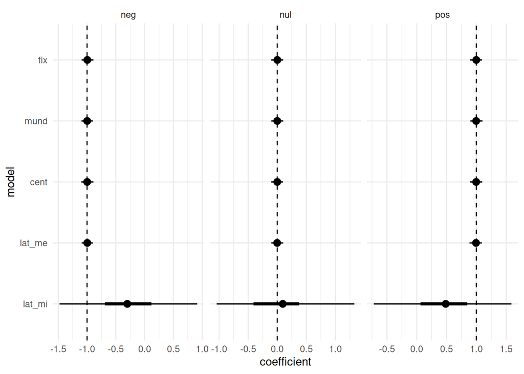

```r
summary2 <- summary_t |>
  filter(!model %in% c("conf", "naive")) |>
  mutate(model = fct_drop(model))

summary2 |>
  ggplot(aes(y = model, x = .value, xmin = .lower, xmax = .upper)) +
  geom_pointinterval() +
  scale_y_discrete(limits = rev(levels(summary2$model))) +
  geom_vline(aes(xintercept = x), linetype = 2, data = trueline) +
  facet_wrap(~ effect, scales = "free_x") +
  labs(x = "coefficient")
```

Aside from the missingness model, all other models seem equivalent. The latent mean models, aside from the additional complexity, each show some issues, either in the translation to Stan code or in the excessively large intervals. Since the fixed-effects model is much easier and faster to fit than the others, it is the estimator of choice. Its downside, not being able to estimate site-level effects, is not of interest here (site-level effects are easily confounded). Also, the fixed-effects formulation is simpler with interactions.

# 6 Models with interactions

Additional care must be taken with interaction terms to recover an unconfounded within-site estimator. The interaction of two variables *x* and *z* can be decomposed into four terms (Giesselmann and Schmidt-Catran 2022, eqq. 7 and 8 without the last term):

$$x_{w}z_{w} + x_{w}\overline{z}+\overline{x}z_{w}+\overline{xz}$$

where *x<sub>w</sub>* represents within-site variations of *x*. Of these terms, only the first represents a true within effect, while the middle two represent cross-level interactions between one variable and average site differences of the other. The last term, whether the interaction is demeaned or not, is constant within a site.

In these models, within-site precipitation fluctuations interact with within-site temperature. In the first scenario, there is no cross-level interactions of within- and between-site temperature differences, or interactions at the site level. Temperature and precipitation are site-centered. This is not necessary in a fixed-effects models, because site means are absorbed in the site term, but it improves model sampling.

## 6.1 Interaction only within sites

```r
set.seed(820)

sim_int_w <- sim |>
  weat_sim(t_y = 1, p_y = -0.5, int_w = -1)
```

```r
fit_int_std_w <- brm(FD ~ t_cent + p_cent + temp:prec + site,
                   data = sim_int_w,
                   prior = prior,
                   file = "fits/sim/sim.int.std.w",
                   seed = 295)

fit_int_std_w
```

```
 Family: gaussian
  Links: mu = identity
Formula: FD ~ t_cent + p_cent + temp:prec + site
   Data: sim_int_w (Number of observations: 512)
  Draws: 4 chains, each with iter = 2000; warmup = 1000; thin = 1;
         total post-warmup draws = 4000

Regression Coefficients:
          Estimate Est.Error l-95% CI u-95% CI Rhat Bulk_ESS Tail_ESS
Intercept    -1.52      0.03    -1.59    -1.45 1.00     2930     2850
t_cent        1.25      0.05     1.14     1.35 1.00     4068     2600
p_cent       -0.36      0.11    -0.58    -0.13 1.00     2190     2401
site1         2.78      0.05     2.68     2.87 1.00     4029     2429
site2        -0.32      0.04    -0.39    -0.24 1.00     4116     2551
site3        -0.78      0.07    -0.90    -0.65 1.00     2683     3046
temp:prec     0.05      0.05    -0.05     0.16 1.00     2074     2516

Further Distributional Parameters:
      Estimate Est.Error l-95% CI u-95% CI Rhat Bulk_ESS Tail_ESS
sigma     0.51      0.02     0.48     0.54 1.00     5073     2986

Draws were sampled using sample(hmc). For each parameter, Bulk_ESS
and Tail_ESS are effective sample size measures, and Rhat is the potential
scale reduction factor on split chains (at convergence, Rhat = 1).
```

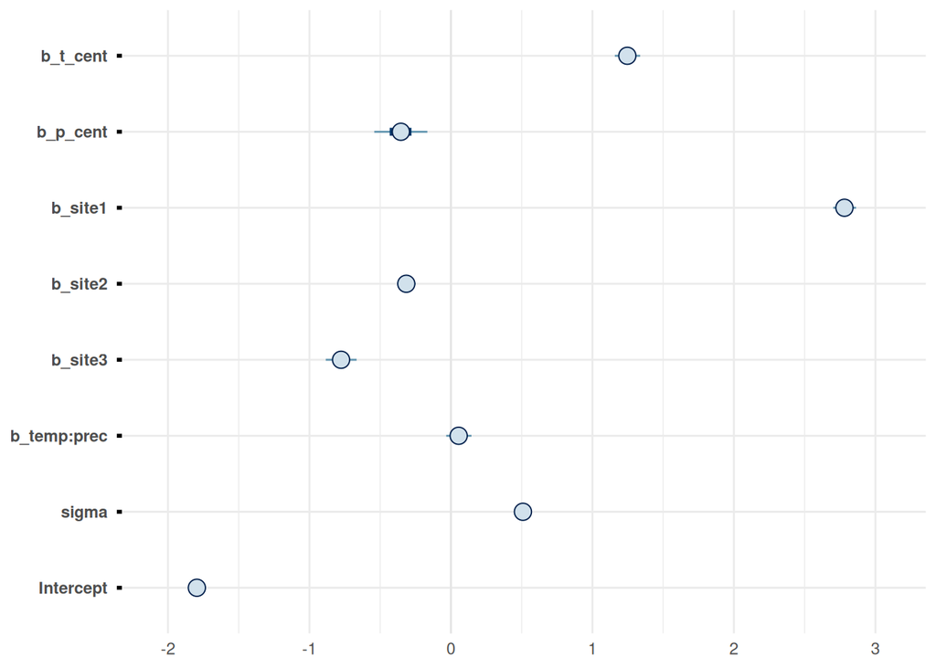

```r
mcmc_intervals(fit_int_std_w, pars = show)
```

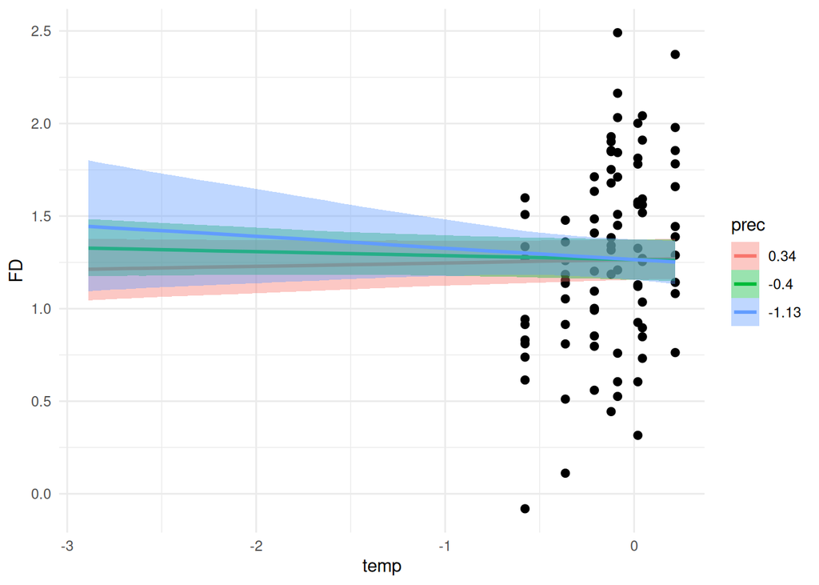

```r
conditional_effects(fit_int_std_w, effects = "temp:prec")
```

```r
fit_int_demean_w <- update(fit_int_std_w,
                           FD ~ t_cent + p_cent + t_cent:p_cent + site,
                           file = "fits/sim/sim.int.dem.w",
                           seed = 295)

fit_int_demean_w
```

```
 Family: gaussian
  Links: mu = identity
Formula: FD ~ t_cent + p_cent + site + t_cent:p_cent
   Data: sim_int_w (Number of observations: 512)
  Draws: 4 chains, each with iter = 2000; warmup = 1000; thin = 1;
         total post-warmup draws = 4000

Regression Coefficients:
              Estimate Est.Error l-95% CI u-95% CI Rhat Bulk_ESS Tail_ESS
Intercept        -1.48      0.02    -1.52    -1.44 1.00     5920     2961
t_cent            1.17      0.05     1.06     1.27 1.00     5278     3444
p_cent           -0.45      0.05    -0.56    -0.35 1.00     6044     3131
site1             2.76      0.04     2.68     2.84 1.00     4613     3202
site2            -0.35      0.04    -0.42    -0.28 1.00     4612     2936
site3            -0.84      0.04    -0.92    -0.76 1.00     4673     2965
t_cent:p_cent    -0.82      0.16    -1.15    -0.49 1.00     5606     2355

Further Distributional Parameters:
      Estimate Est.Error l-95% CI u-95% CI Rhat Bulk_ESS Tail_ESS
sigma     0.50      0.02     0.47     0.53 1.00     6640     3076

Draws were sampled using sample(hmc). For each parameter, Bulk_ESS
and Tail_ESS are effective sample size measures, and Rhat is the potential
scale reduction factor on split chains (at convergence, Rhat = 1).
```

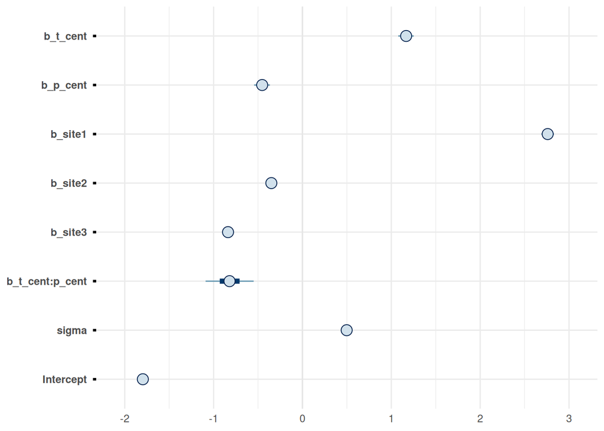

```r
mcmc_intervals(fit_int_demean_w, pars = show)
```

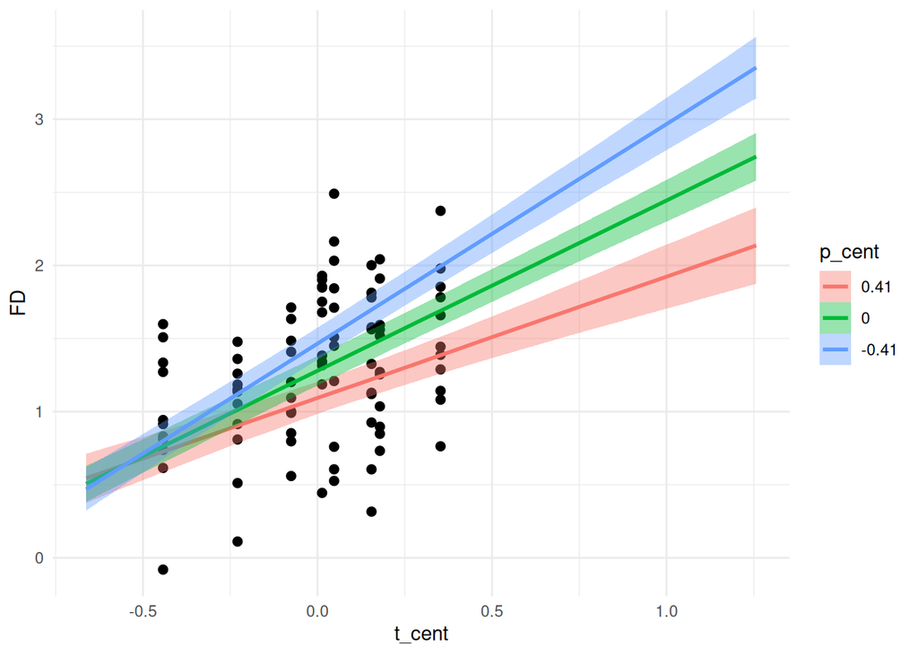

```r
conditional_effects(fit_int_demean_w, effects = "t_cent:p_cent")
```

```r
fit_int_dd_w <- update(fit_int_std_w,
                       FD ~ t_cent + p_cent + t_x_p + site,
                       newdata = sim_int_w,
                       file = "fits/sim/sim.int.dd.w",
                       seed = 295)

fit_int_dd_w
```

```
 Family: gaussian
  Links: mu = identity
Formula: FD ~ t_cent + p_cent + t_x_p + site
   Data: sim_int_w (Number of observations: 512)
  Draws: 4 chains, each with iter = 2000; warmup = 1000; thin = 1;
         total post-warmup draws = 4000

Regression Coefficients:
          Estimate Est.Error l-95% CI u-95% CI Rhat Bulk_ESS Tail_ESS
Intercept    -1.49      0.02    -1.54    -1.44 1.00     6897     3269
t_cent        1.17      0.05     1.06     1.27 1.00     6781     2984
p_cent       -0.45      0.05    -0.56    -0.35 1.00     7340     3392
t_x_p        -0.82      0.16    -1.14    -0.49 1.00     6280     3117
site1         2.76      0.04     2.68     2.85 1.00     4341     3226
site2        -0.33      0.04    -0.40    -0.26 1.00     5048     3238
site3        -0.83      0.04    -0.91    -0.75 1.00     4966     3009

Further Distributional Parameters:
      Estimate Est.Error l-95% CI u-95% CI Rhat Bulk_ESS Tail_ESS
sigma     0.50      0.02     0.47     0.53 1.00     6683     2981

Draws were sampled using sample(hmc). For each parameter, Bulk_ESS
and Tail_ESS are effective sample size measures, and Rhat is the potential
scale reduction factor on split chains (at convergence, Rhat = 1).
```

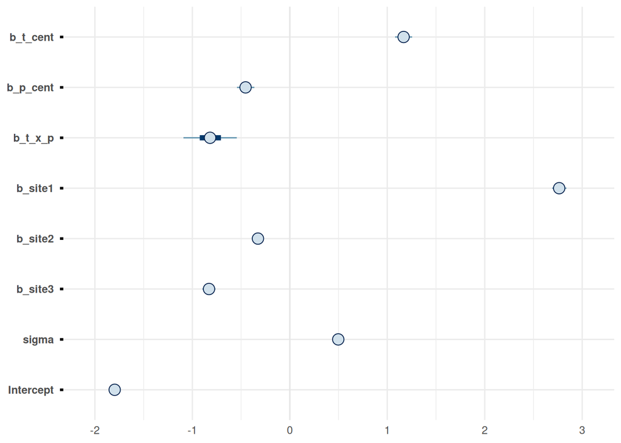

```r
mcmc_intervals(fit_int_dd_w, pars = show)
```

## 6.2 With interaction confounding

### 6.2.1 Site-level interaction

In the following models, there is an additional interaction between site-level temperature and precipitation.

```r
set.seed(820)

sim_int_w_b <- sim |>
  weat_sim(t_y = 1, p_y = -0.5, int_w = -1, int_b = 1)
```

```r
fit_int_std_w_b <- brm(FD ~ t_cent + p_cent + temp:prec + site,
                       data = sim_int_w_b,
                       prior = prior,
                       file = "fits/sim/sim.int.std.w.b",
                       seed = 295)

fit_int_std_w_b
```

```
 Family: gaussian
  Links: mu = identity
Formula: FD ~ t_cent + p_cent + temp:prec + site
   Data: sim_int_w_b (Number of observations: 512)
  Draws: 4 chains, each with iter = 2000; warmup = 1000; thin = 1;
         total post-warmup draws = 4000

Regression Coefficients:
          Estimate Est.Error l-95% CI u-95% CI Rhat Bulk_ESS Tail_ESS
Intercept    -0.97      0.04    -1.04    -0.90 1.00     2420     2693
t_cent        1.25      0.05     1.14     1.36 1.00     4530     2916
p_cent       -0.34      0.12    -0.57    -0.12 1.00     1879     2266
site1         2.46      0.05     2.36     2.55 1.00     3500     2722
site2        -0.61      0.04    -0.69    -0.53 1.00     4221     2980
site3        -1.75      0.07    -1.88    -1.62 1.00     2015     2328
temp:prec     0.06      0.06    -0.05     0.17 1.00     1656     1988

Further Distributional Parameters:
      Estimate Est.Error l-95% CI u-95% CI Rhat Bulk_ESS Tail_ESS
sigma     0.51      0.02     0.48     0.54 1.00     4792     2773

Draws were sampled using sample(hmc). For each parameter, Bulk_ESS
and Tail_ESS are effective sample size measures, and Rhat is the potential
scale reduction factor on split chains (at convergence, Rhat = 1).
```

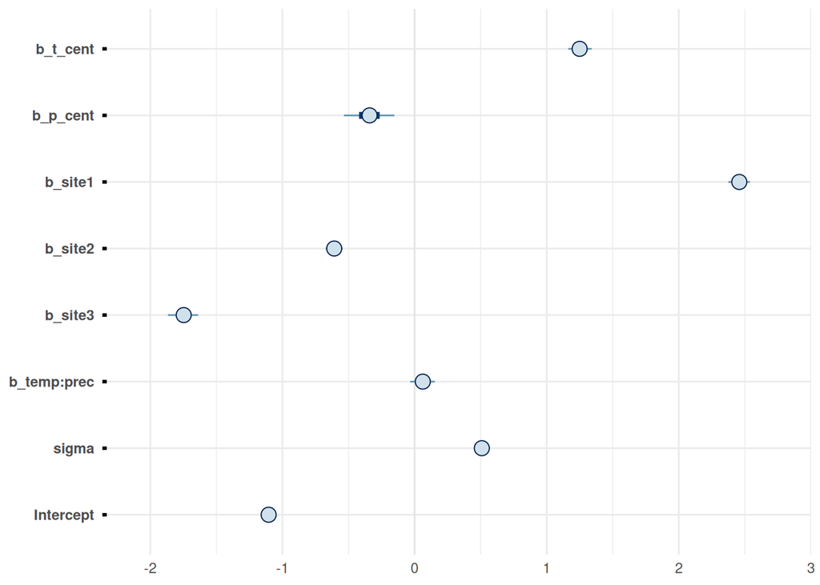

```r
mcmc_intervals(fit_int_std_w_b, pars = show)
```

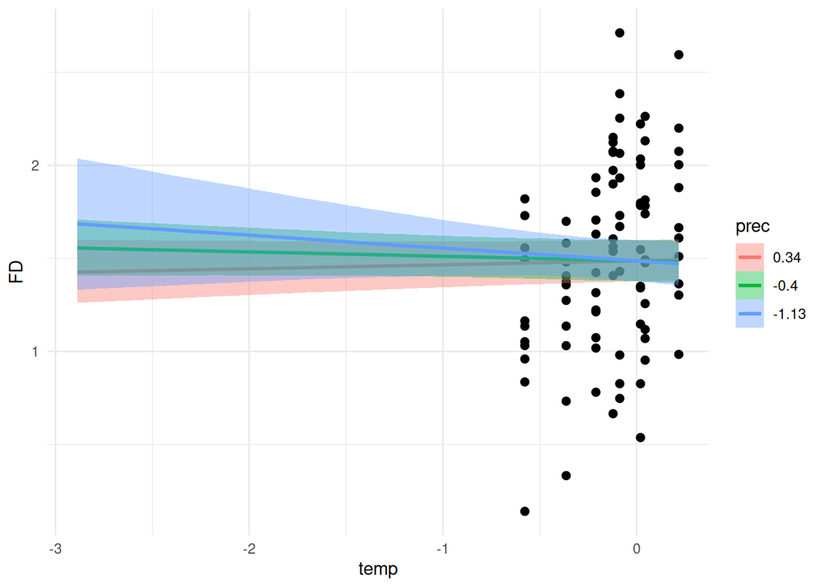

```r
conditional_effects(fit_int_std_w_b, effects = "temp:prec")
```

```r
fit_int_demean_w_b <- update(fit_int_std_w_b,
                             FD ~ t_cent + p_cent + t_cent:p_cent + site,
                             file = "fits/sim/sim.int.dem.w.b",
                             seed = 295)

fit_int_demean_w_b
```

```
 Family: gaussian
  Links: mu = identity
Formula: FD ~ t_cent + p_cent + site + t_cent:p_cent
   Data: sim_int_w_b (Number of observations: 512)
  Draws: 4 chains, each with iter = 2000; warmup = 1000; thin = 1;
         total post-warmup draws = 4000

Regression Coefficients:
              Estimate Est.Error l-95% CI u-95% CI Rhat Bulk_ESS Tail_ESS
Intercept        -0.93      0.02    -0.98    -0.89 1.00     6628     3238
t_cent            1.17      0.05     1.06     1.28 1.00     6401     3120
p_cent           -0.45      0.06    -0.56    -0.34 1.00     6519     2869
site1             2.43      0.04     2.35     2.52 1.00     4513     3388
site2            -0.64      0.04    -0.71    -0.57 1.00     4481     3163
site3            -1.82      0.04    -1.90    -1.74 1.00     4575     2898
t_cent:p_cent    -0.82      0.17    -1.15    -0.51 1.00     5626     3196

Further Distributional Parameters:
      Estimate Est.Error l-95% CI u-95% CI Rhat Bulk_ESS Tail_ESS
sigma     0.50      0.02     0.47     0.53 1.00     6441     2840

Draws were sampled using sample(hmc). For each parameter, Bulk_ESS
and Tail_ESS are effective sample size measures, and Rhat is the potential
scale reduction factor on split chains (at convergence, Rhat = 1).
```

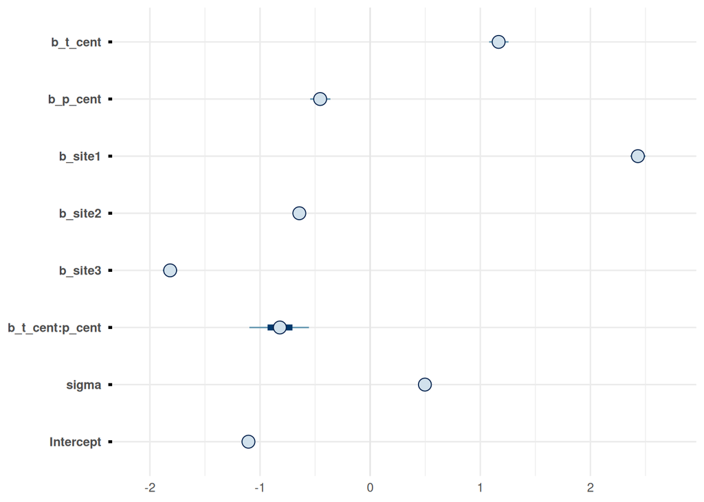

```r
mcmc_intervals(fit_int_demean_w_b, pars = show)
```

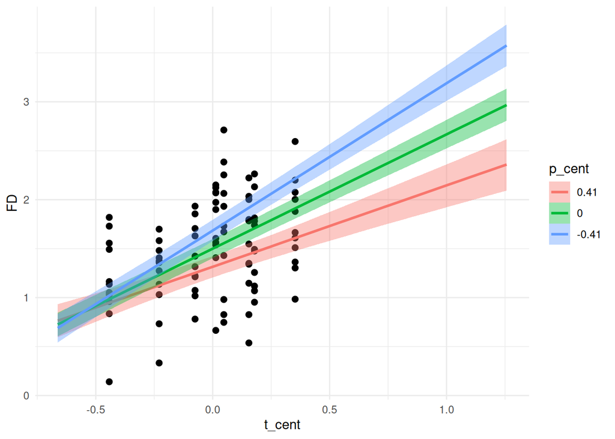

```r
conditional_effects(fit_int_demean_w_b, effects = "t_cent:p_cent")
```

```r
fit_int_dd_w_b <- update(fit_int_std_w_b,
                         FD ~ t_cent + p_cent + t_x_p + site,
                         newdata = sim_int_w_b,
                         file = "fits/sim/sim.int.dd.w.b",
                         seed = 295)

fit_int_dd_w_b
```

```
 Family: gaussian
  Links: mu = identity
Formula: FD ~ t_cent + p_cent + t_x_p + site
   Data: sim_int_w_b (Number of observations: 512)
  Draws: 4 chains, each with iter = 2000; warmup = 1000; thin = 1;
         total post-warmup draws = 4000

Regression Coefficients:
          Estimate Est.Error l-95% CI u-95% CI Rhat Bulk_ESS Tail_ESS
Intercept    -0.94      0.02    -0.99    -0.89 1.00     6393     3085
t_cent        1.17      0.05     1.06     1.28 1.00     5851     3111
p_cent       -0.45      0.05    -0.56    -0.35 1.00     6934     3014
t_x_p        -0.82      0.16    -1.12    -0.50 1.00     6128     3180
site1         2.44      0.04     2.35     2.52 1.00     4348     3480
site2        -0.62      0.04    -0.69    -0.55 1.00     4311     3079
site3        -1.81      0.04    -1.89    -1.73 1.00     4859     3055

Further Distributional Parameters:
      Estimate Est.Error l-95% CI u-95% CI Rhat Bulk_ESS Tail_ESS
sigma     0.50      0.02     0.47     0.53 1.00     5992     3290

Draws were sampled using sample(hmc). For each parameter, Bulk_ESS
and Tail_ESS are effective sample size measures, and Rhat is the potential
scale reduction factor on split chains (at convergence, Rhat = 1).
```

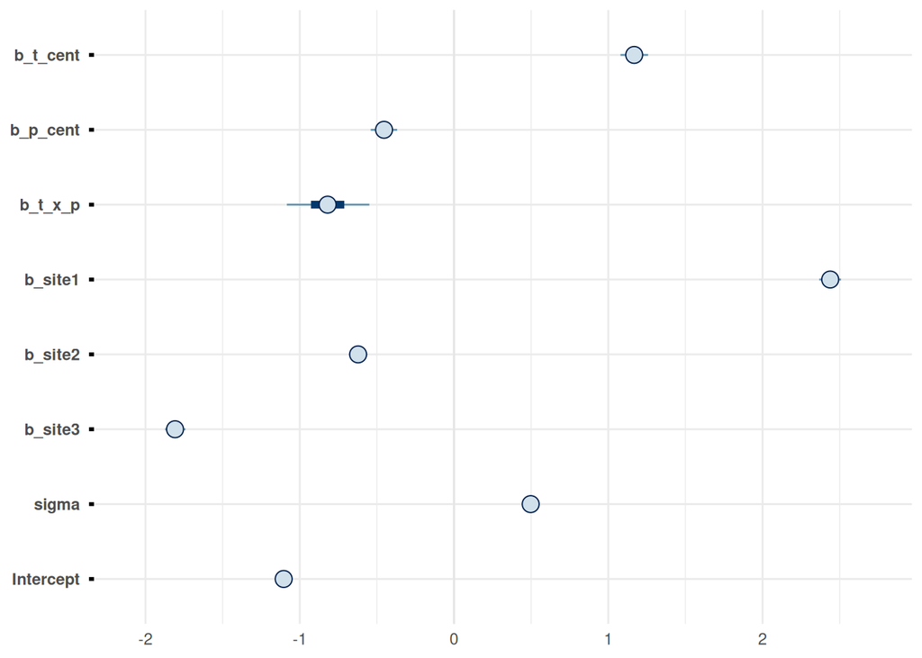

```r
mcmc_intervals(fit_int_dd_w_b, pars = show)
```

### 6.2.2 Cross-level interaction

In the following models there is an additional cross-level interaction of within-site temperature changes with site-level precipitation.

```r
set.seed(820)

sim_int_w_c1 <- sim |>
  weat_sim(t_y = 1, p_y = -0.5, int_w = -1, int_c1 = 1)
```

```r
fit_int_std_w_c1 <- brm(FD ~ t_cent + p_cent + temp:prec + site,
                        data = sim_int_w_c1,
                        prior = prior,
                        file = "fits/sim/sim.int.std.w.c1",
                        seed = 295)

fit_int_std_w_c1
```

```
 Family: gaussian
  Links: mu = identity
Formula: FD ~ t_cent + p_cent + temp:prec + site
   Data: sim_int_w_c1 (Number of observations: 512)
  Draws: 4 chains, each with iter = 2000; warmup = 1000; thin = 1;
         total post-warmup draws = 4000

Regression Coefficients:
          Estimate Est.Error l-95% CI u-95% CI Rhat Bulk_ESS Tail_ESS
Intercept    -1.78      0.04    -1.86    -1.70 1.00     2427     2584
t_cent        1.25      0.06     1.13     1.38 1.00     4129     2729
p_cent        0.16      0.13    -0.08     0.41 1.00     2122     2724
site1         2.94      0.05     2.83     3.04 1.00     4059     3108
site2        -0.13      0.04    -0.22    -0.05 1.00     3982     2608
site3        -0.60      0.08    -0.75    -0.46 1.00     2444     2728
temp:prec     0.39      0.06     0.27     0.50 1.00     1905     2322

Further Distributional Parameters:
      Estimate Est.Error l-95% CI u-95% CI Rhat Bulk_ESS Tail_ESS
sigma     0.57      0.02     0.53     0.60 1.00     5076     2468

Draws were sampled using sample(hmc). For each parameter, Bulk_ESS
and Tail_ESS are effective sample size measures, and Rhat is the potential
scale reduction factor on split chains (at convergence, Rhat = 1).
```

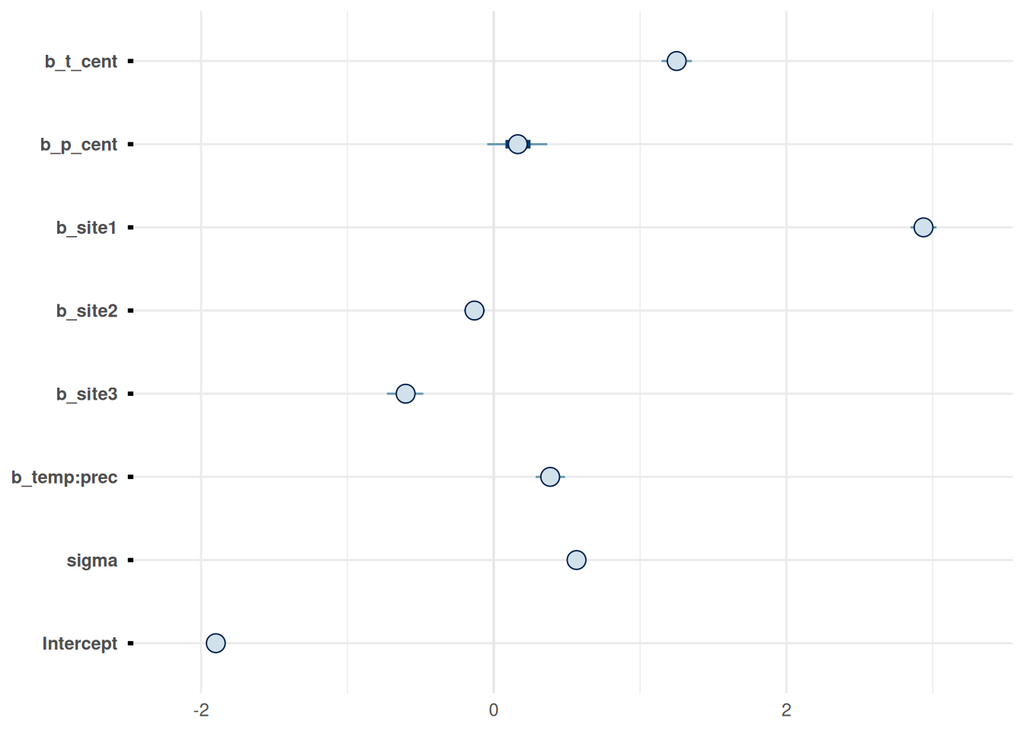

```r
mcmc_intervals(fit_int_std_w_c1, pars = show)
```

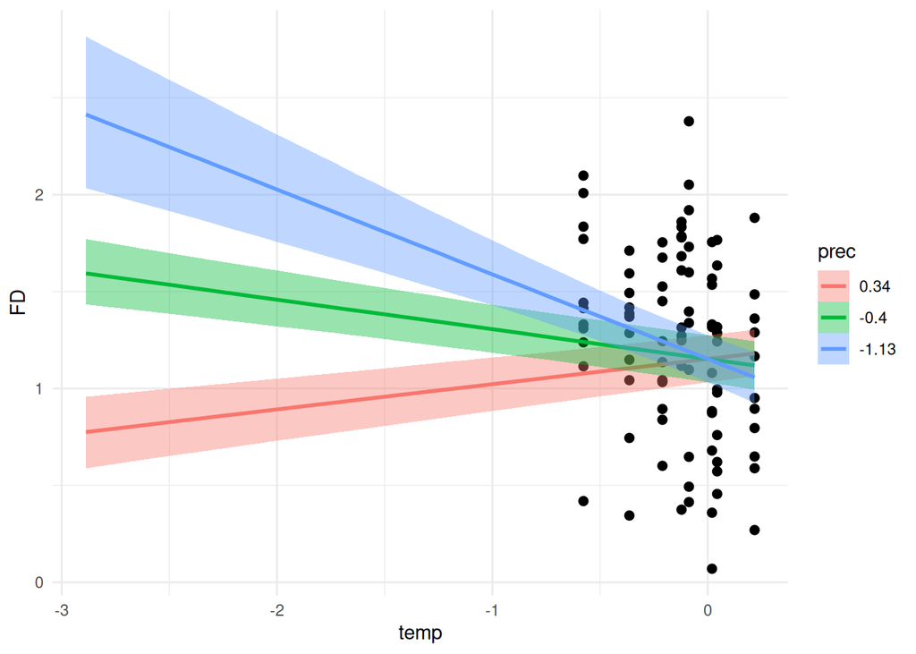

```r
conditional_effects(fit_int_std_w_c1, effects = "temp:prec")
```

```r
fit_int_demean_w_c1 <- update(fit_int_std_w_c1,
                              FD ~ t_cent + p_cent + t_cent:p_cent + site,
                              file = "fits/sim/sim.int.dem.w.c1",
                              seed = 295)

fit_int_demean_w_c1
```

```
 Family: gaussian
  Links: mu = identity
Formula: FD ~ t_cent + p_cent + site + t_cent:p_cent
   Data: sim_int_w_c1 (Number of observations: 512)
  Draws: 4 chains, each with iter = 2000; warmup = 1000; thin = 1;
         total post-warmup draws = 4000

Regression Coefficients:
              Estimate Est.Error l-95% CI u-95% CI Rhat Bulk_ESS Tail_ESS
Intercept        -1.59      0.03    -1.64    -1.54 1.00     6877     3024
t_cent            1.08      0.06     0.96     1.21 1.00     5688     3083
p_cent           -0.53      0.06    -0.65    -0.41 1.00     6592     2995
site1             2.81      0.05     2.71     2.91 1.00     3776     3010
site2            -0.23      0.04    -0.32    -0.15 1.00     4252     3130
site3            -0.99      0.05    -1.08    -0.90 1.00     4029     3046
t_cent:p_cent    -0.82      0.20    -1.20    -0.43 1.00     5157     2965

Further Distributional Parameters:
      Estimate Est.Error l-95% CI u-95% CI Rhat Bulk_ESS Tail_ESS
sigma     0.58      0.02     0.54     0.61 1.00     5398     2930

Draws were sampled using sample(hmc). For each parameter, Bulk_ESS
and Tail_ESS are effective sample size measures, and Rhat is the potential
scale reduction factor on split chains (at convergence, Rhat = 1).
```

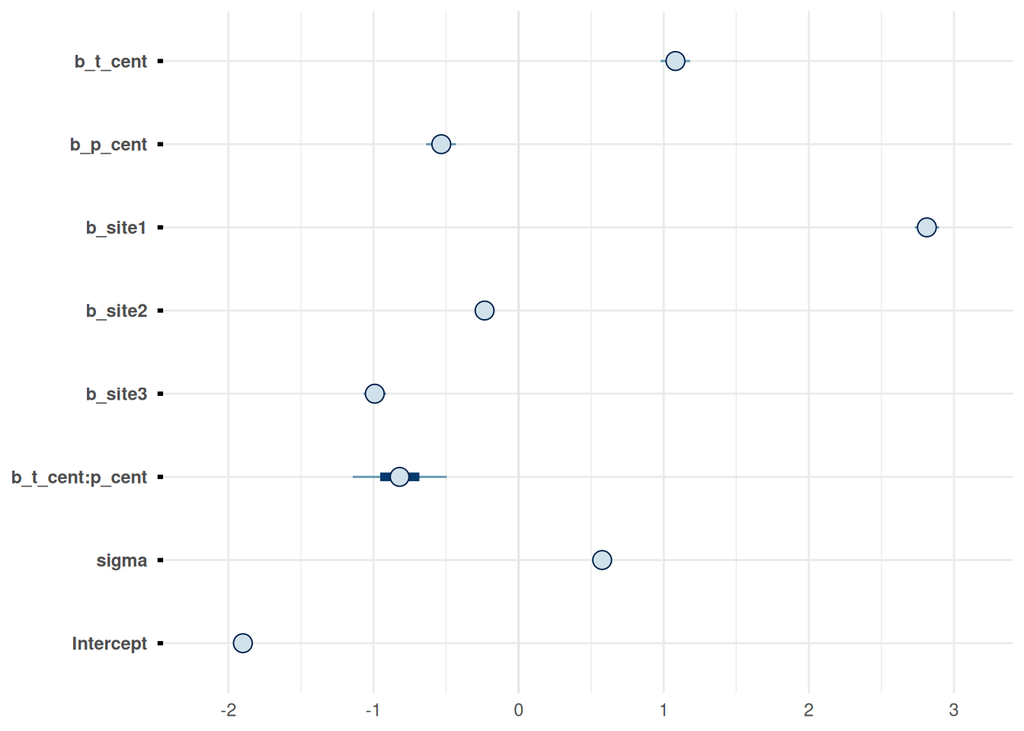

```r
mcmc_intervals(fit_int_demean_w_c1, pars = show)
```

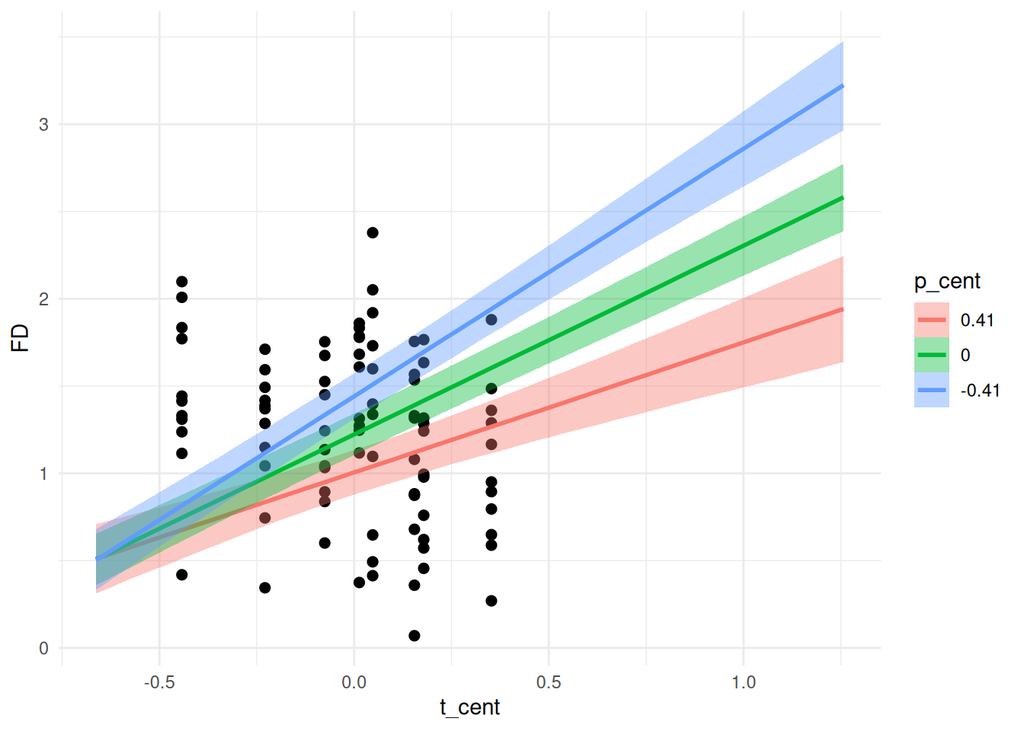

```r
conditional_effects(fit_int_demean_w_c1, effects = "t_cent:p_cent")
```

```r
fit_int_dd_w_c1 <- update(fit_int_std_w_c1,
                          FD ~ t_cent + p_cent + t_x_p + site,
                          newdata = sim_int_w_c1,
                          file = "fits/sim/sim.int.dd.w.c1",
                          seed = 295)

fit_int_dd_w_c1
```

```
 Family: gaussian
  Links: mu = identity
Formula: FD ~ t_cent + p_cent + t_x_p + site
   Data: sim_int_w_c1 (Number of observations: 512)
  Draws: 4 chains, each with iter = 2000; warmup = 1000; thin = 1;
         total post-warmup draws = 4000

Regression Coefficients:
          Estimate Est.Error l-95% CI u-95% CI Rhat Bulk_ESS Tail_ESS
Intercept    -1.60      0.03    -1.65    -1.55 1.00     6527     3278
t_cent        1.08      0.06     0.96     1.20 1.00     4835     2916
p_cent       -0.53      0.06    -0.65    -0.41 1.00     5500     2985
t_x_p        -0.82      0.18    -1.17    -0.48 1.00     5085     3091
site1         2.82      0.05     2.72     2.91 1.00     3675     2940
site2        -0.21      0.04    -0.29    -0.13 1.00     4297     3231
site3        -0.98      0.05    -1.07    -0.89 1.00     4365     2904

Further Distributional Parameters:
      Estimate Est.Error l-95% CI u-95% CI Rhat Bulk_ESS Tail_ESS
sigma     0.58      0.02     0.54     0.61 1.00     6110     3107

Draws were sampled using sample(hmc). For each parameter, Bulk_ESS
and Tail_ESS are effective sample size measures, and Rhat is the potential
scale reduction factor on split chains (at convergence, Rhat = 1).
```

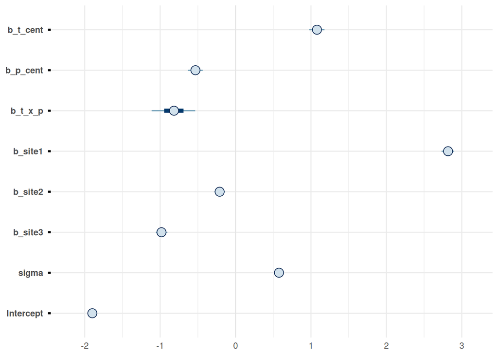

```r
mcmc_intervals(fit_int_dd_w_c1, pars = show)
```

### 6.2.3 Both

The following models have interactions within site, at site level, and cross-level.

```r
set.seed(820)

sim_int_x <- sim |>
  weat_sim(t_y = 1, p_y = -0.5, int_w = -1, int_c1 = 1, int_b = 1)
```

```r
fit_int_std_x <- brm(FD ~ t_cent + p_cent + temp:prec + site,
                     data = sim_int_x,
                     prior = prior,
                     file = "fits/sim/sim.int.std.x",
                     seed = 295)

fit_int_std_x
```

```
 Family: gaussian
  Links: mu = identity
Formula: FD ~ t_cent + p_cent + temp:prec + site
   Data: sim_int_x (Number of observations: 512)
  Draws: 4 chains, each with iter = 2000; warmup = 1000; thin = 1;
         total post-warmup draws = 4000

Regression Coefficients:
          Estimate Est.Error l-95% CI u-95% CI Rhat Bulk_ESS Tail_ESS
Intercept    -1.24      0.04    -1.31    -1.16 1.00     2323     2432
t_cent        1.25      0.06     1.13     1.37 1.00     4834     2578
p_cent        0.17      0.13    -0.08     0.42 1.00     1831     2178
site1         2.61      0.05     2.50     2.71 1.00     3777     2879
site2        -0.43      0.04    -0.51    -0.34 1.00     4627     2869
site3        -1.58      0.08    -1.73    -1.43 1.00     2130     2591
temp:prec     0.39      0.06     0.27     0.51 1.00     1727     1965

Further Distributional Parameters:
      Estimate Est.Error l-95% CI u-95% CI Rhat Bulk_ESS Tail_ESS
sigma     0.57      0.02     0.53     0.60 1.00     5381     2940

Draws were sampled using sample(hmc). For each parameter, Bulk_ESS
and Tail_ESS are effective sample size measures, and Rhat is the potential
scale reduction factor on split chains (at convergence, Rhat = 1).
```

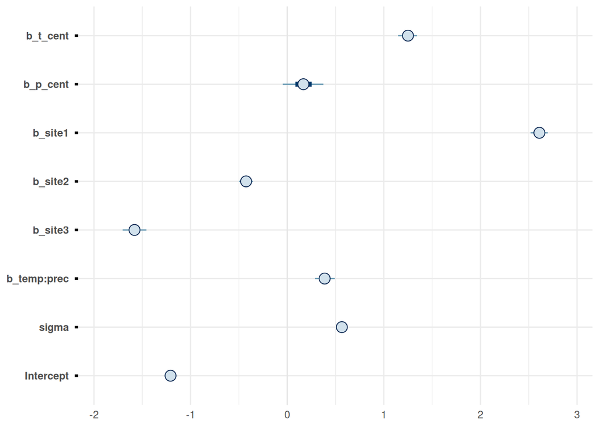

```r
mcmc_intervals(fit_int_std_x, pars = show)
```

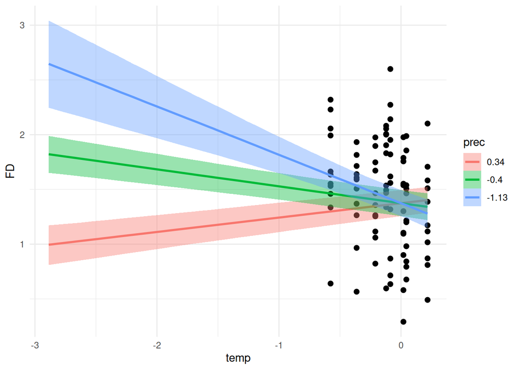

```r
conditional_effects(fit_int_std_x, effects = "temp:prec")
```

```r
fit_int_demean_x <- update(fit_int_std_x,
                           FD ~ t_cent + p_cent + t_cent:p_cent + site,
                           file = "fits/sim/sim.int.dem.x",
                           seed = 295)

fit_int_demean_x
```

```
 Family: gaussian
  Links: mu = identity
Formula: FD ~ t_cent + p_cent + site + t_cent:p_cent
   Data: sim_int_x (Number of observations: 512)
  Draws: 4 chains, each with iter = 2000; warmup = 1000; thin = 1;
         total post-warmup draws = 4000

Regression Coefficients:
              Estimate Est.Error l-95% CI u-95% CI Rhat Bulk_ESS Tail_ESS
Intercept        -1.04      0.03    -1.09    -0.99 1.00     5612     2773
t_cent            1.08      0.06     0.96     1.20 1.00     6476     3302
p_cent           -0.53      0.06    -0.66    -0.41 1.00     7522     3417
site1             2.49      0.05     2.39     2.58 1.00     3907     2857
site2            -0.53      0.04    -0.61    -0.44 1.00     4454     3238
site3            -1.97      0.05    -2.07    -1.88 1.00     4806     3113
t_cent:p_cent    -0.82      0.19    -1.19    -0.45 1.00     6411     2945

Further Distributional Parameters:
      Estimate Est.Error l-95% CI u-95% CI Rhat Bulk_ESS Tail_ESS
sigma     0.58      0.02     0.54     0.61 1.00     7718     3039

Draws were sampled using sample(hmc). For each parameter, Bulk_ESS
and Tail_ESS are effective sample size measures, and Rhat is the potential
scale reduction factor on split chains (at convergence, Rhat = 1).
```